# Keene and Susy - All samples together

Charlie Whittaker

5/2/2022

# Load libraries

```r
library(openxlsx)
library(ggplot2)
library(tidyverse)
library(reprex)
library(matrixStats)
library(XML)
library(ggrepel)
library(DESeq2)
library(apeglm)
library(ComplexHeatmap)
library(dplyr)
library(readxl)
library(readr)
library(tximport)
library(edgeR)
library(MAGeCKFlute)
library(clusterProfiler)
library(ggpubr)
library(gprofiler2)
library(clusterProfiler)
library(AnnotationDbi)
library(org.Mm.eg.db)
```

```r
library(extrafont)
loadfonts(device = "win")
```

# Count QC

```r
# countsummary <- read.delim("PrePost.countsummary.txt", check.names = FALSE)
#
# BarView(countsummary, x = "Label", y = "GiniIndex",
#         ylab = "Gini index", main = "Evenness of sgRNA reads")
#
# countsummary$Missed = log10(countsummary$Zerocounts)
# BarView(countsummary, x = "Label", y = "Missed", fill = "#394E80",
#         ylab = "Log10 missed gRNAs", main = "Missed sgRNAs")
#
# MapRatesView(countsummary)
```

# Running full FluteRRA pipeline

```r
#file1 = file.path(system.file("extdata", package = "MAGeCKFlute"),
#                  "PostvPre.gene_summary.txt")
## path to the sgRNA summary file (optional)
#file2 = file.path(system.file("extdata", package = "MAGeCKFlute"),
#                  "PostvPre.sgrna_summary.txt")

#FluteRRA("PostvPre.gene_summary.txt",incorporateDepmap = FALSE, keytype = "Symbol", proj="PostVPre", organism="mmu", outdir = "./")
#FluteRRA("PostvPre.gene_summary.txt", "PostvPre.sgrna_summary.txt"", proj="PostVPre_plus_sgRNA", organism="mmu", outdir = "./")
```

# Import count tables

```r
all.counts <- read.xlsx("stockCounts.xlsx")
```

# Yunpeng’s Processing

The following is text from the paper:

“Sample quality control was performed by counting the number of gRNA sequences that show at least 30 reads in each sample. Samples with more than 30% of gRNA sequences that were filtered out after the above procedure were excluded from further analyses.

Guide RNA-level read counts were scaled by total read count for each sample and logarithm-transformed.

Gene-level enrichment and depletion scores were computed by averaging log-normalized read counts across all gRNA sequences against each gene.

Input samples were used as a baseline for computing scores. Specifically, every gene was first assigned an ‘essentiality score’ computed as the difference (i.e. log-fold change) between the average gene-level counts for the gene across replicates and that in the input sample.

The CAR-T therapy enrichment/depletion score for a given gene is computed as the difference between the essentiality scores of that gene in anti-mCD19 CAR-T cell treated samples and in anti-hEGFRvIII CAR-T cell treated samples.

For sample groups that have at least 2 samples retained after quality control, Student’s t-tests were performed to obtain p-values for assessing significance of difference between the scores in the treatment group and the control group.”

## QC Method

```r
forQC <- all.counts %>% dplyr::select(-c(Gene,sgRNA))
row.count <- nrow(forQC)
sub30 <- as.data.frame(colSums(forQC < 30))
sub30.percent <- as.data.frame((colSums(forQC < 30)/row.count)*100)

# List bad samples
row.names(sub30.percent %>% filter((colSums(forQC < 30)/row.count)*100 > 30))
```

```
[1] "AR2475_SP"
```

## Yunpeng’s Normalization

```r
forNorm <- all.counts %>% dplyr::select(-c(Gene))
rownames(forNorm) <- forNorm[,1]
forNorm <- forNorm %>% dplyr::select(-c(sgRNA))

dat2 <- apply(forNorm,2,function(x){x/(sum(x)/1000000)})
dat2 <- log((dat2+1),2)
```

## Grouping samples and creating means

```r
dat3 <- all.counts %>% dplyr::select(c("sgRNA", "Gene"))
rownames(dat3) <- dat3[,1]

dat2.df <- as.data.frame(dat2)
dat2.df <- dat2.df %>% mutate(ahEGFRv3_1to10.av = rowMeans(dplyr::select(., starts_with("ahEGFRv3_1to10"))))
dat2.df <- dat2.df %>% mutate(ahEGFRv3_1to2.av = rowMeans(dplyr::select(., starts_with("ahEGFRv3_1to2"))))
dat2.df <- dat2.df %>% mutate(amCD19_1to10.av = rowMeans(dplyr::select(., starts_with("amCD19_1to10"))))
dat2.df <- dat2.df %>% mutate(amCD19_1to2.av = rowMeans(dplyr::select(., starts_with("amCD19_1to2"))))
dat2.df <- dat2.df %>% mutate(NoCAR_T.av = rowMeans(dplyr::select(., starts_with("NoCAR_T"))))
dat2.df <- dat2.df %>% mutate(amCD19_1to2.av = rowMeans(dplyr::select(., starts_with("amCD19_1to2"))))
dat2.df <- dat2.df %>% mutate(Input1_DOI.av = rowMeans(dplyr::select(., starts_with("Input1_DOI"))))
dat2.df <- dat2.df %>% mutate(Input2_ACT.av = rowMeans(dplyr::select(., starts_with("Input2_ACT"))))
dat2.df <- dat2.df %>% mutate(BM_cd19.15m.av = rowMeans(dplyr::select(., AR2480_BM,AR2481_BM,AR2482_BM,AR2483_BM)))
dat2.df <- dat2.df %>% mutate(BM_egfr.15m.av = rowMeans(dplyr::select(., AR2466_BM,AR2467_BM,AR2468_BM,AR2469_BM)))
dat2.df <- dat2.df %>% mutate(BM_cd19.10m.av = rowMeans(dplyr::select(., AR2473_BM,AR2474_BM,AR2475_BM,AR2476_BM)))
dat2.df <- dat2.df %>% mutate(SP_cd19.15m.av = rowMeans(dplyr::select(., AR2480_SP,AR2481_SP,AR2482_SP,AR2483_SP)))
dat2.df <- dat2.df %>% mutate(SP_egfr.15m.av = rowMeans(dplyr::select(., AR2466_SP,AR2467_SP,AR2468_SP,AR2469_SP)))
# AR2475_SP excluded due to the 30% less than 30 QC rule
dat2.df <- dat2.df %>% mutate(SP_cd19.10m.av = rowMeans(dplyr::select(., AR2473_SP,AR2474_SP,AR2476_SP)))
dat2.df <- dat2.df %>% dplyr::select(ends_with(".av"))
Av.df <- merge(dat3,dat2.df, by=0, all=TRUE)
```

## Preparing guide-level fold changes

```r
#In vitro
Av.df <- Av.df %>% mutate(cd19_1to2_v_egfr_1to2.fc = ((amCD19_1to2.av-Input1_DOI.av)-(ahEGFRv3_1to2.av-Input1_DOI.av)))
Av.df <- Av.df %>% mutate(cd19_1to10_v_egfr_1to10.fc = ((amCD19_1to10.av-Input1_DOI.av)-(ahEGFRv3_1to10.av-Input1_DOI.av)))
#In vivo
Av.df <- Av.df %>% mutate(BM_cd19.15m_v_egfr.15m.fc = ((BM_cd19.15m.av-Input1_DOI.av)-(BM_egfr.15m.av-Input1_DOI.av)))
Av.df <- Av.df %>% mutate(BM_cd19.10m_v_egfr.15m.fc = ((BM_cd19.10m.av-Input1_DOI.av)-(BM_egfr.15m.av-Input1_DOI.av)))
Av.df <- Av.df %>% mutate(SP_cd19.15m_v_egfr.15m.fc = ((BM_cd19.15m.av-Input1_DOI.av)-(BM_egfr.15m.av-Input1_DOI.av)))
Av.df <- Av.df %>% mutate(SP_cd19.10m_v_egfr.15m.fc = ((BM_cd19.10m.av-Input1_DOI.av)-(BM_egfr.15m.av-Input1_DOI.av)))
```

## Preparing gene-level fold changes

```r
cd19_1to2_v_egfr_1to2.fc.Gene <- Av.df %>% group_by(Gene) %>% summarize(cd19_1to2_v_egfr_1to2.fc.Gene = mean(cd19_1to2_v_egfr_1to2.fc, na.rm = TRUE))
cd19_1to10_v_egfr_1to10.fc.Gene <- Av.df %>% group_by(Gene) %>% summarize(cd19_1to10_v_egfr_1to10.fc.Gene = mean(cd19_1to10_v_egfr_1to10.fc, na.rm = TRUE))
BM_cd19.15m_v_egfr.15m.fc.Gene <- Av.df %>% group_by(Gene) %>% summarize(BM_cd19.15m_v_egfr.15m.fc.Gene = mean(BM_cd19.15m_v_egfr.15m.fc, na.rm = TRUE))
BM_cd19.10m_v_egfr.15m.fc.Gene <- Av.df %>% group_by(Gene) %>% summarize(BM_cd19.10m_v_egfr.15m.fc.Gene = mean(BM_cd19.10m_v_egfr.15m.fc, na.rm = TRUE))
SP_cd19.15m_v_egfr.15m.fc.Gene <- Av.df %>% group_by(Gene) %>% summarize(SP_cd19.15m_v_egfr.15m.fc.Gene = mean(SP_cd19.15m_v_egfr.15m.fc, na.rm = TRUE))
SP_cd19.10m_v_egfr.15m.fc.Gene <- Av.df %>% group_by(Gene) %>% summarize(SP_cd19.10m_v_egfr.15m.fc.Gene = mean(SP_cd19.10m_v_egfr.15m.fc, na.rm = TRUE))
```

## Assembling gene-level fold changes

```r
GeneMeans <- cbind(cd19_1to2_v_egfr_1to2.fc.Gene,cd19_1to10_v_egfr_1to10.fc.Gene,BM_cd19.15m_v_egfr.15m.fc.Gene,BM_cd19.10m_v_egfr.15m.fc.Gene,
                   SP_cd19.15m_v_egfr.15m.fc.Gene,SP_cd19.10m_v_egfr.15m.fc.Gene)
rownames(GeneMeans) <- GeneMeans[,1]
GeneMeans <- GeneMeans %>% dplyr::select(-Gene)
GeneMeans <- tibble::rownames_to_column(GeneMeans, "Gene")
#write.xlsx(GeneMeans, file="LFC_GeneMeans.xlsx")
```

## Make Plots

```r
Fccolumns <- colnames(GeneMeans[-1])

for (i in Fccolumns){
  sorted_df <- GeneMeans %>% dplyr::select(all_of(i),Gene) %>% arrange(get(i))
  sorted_df$rank <- c(1:nrow(sorted_df))
  colnames(sorted_df) <- c("LFC","gene","rank")
  sorted_df_top <- sorted_df[sorted_df$rank <= 10 | sorted_df$rank >= (nrow(sorted_df)-9),]
  sorted_df$color <- "others"
  sorted_df$color[match(c("Jak1","Jak2","Stat1","Ifngr1","H2-T23","Cd19"),sorted_df$gene)] <- "hits"
  df_to_highlight <- sorted_df[match(c('Jak2','Stat1','Ifngr1','H2-T23','Cd19'),sorted_df$gene),]
  assign(paste0(i,".plot"),ggplot(sorted_df, aes(x=rank, y=LFC)) + geom_point(aes(size=abs(LFC), fill = color),shape=21, color='grey50') +
  theme_bw() + geom_point(data = df_to_highlight, aes(size=abs(LFC), fill = color),shape=21, color='grey50') + geom_label_repel(data=df_to_highlight, aes(label = gene)) +
  theme(panel.border = element_blank(), panel.grid.major = element_blank(), panel.grid.minor = element_blank(), axis.line = element_line(colour = "black")) +
  theme(axis.text=element_text(size=20)) + ggtitle(i) +
  scale_y_continuous(breaks=seq(-6,6,2), limits=c(-7,7)))
}
```

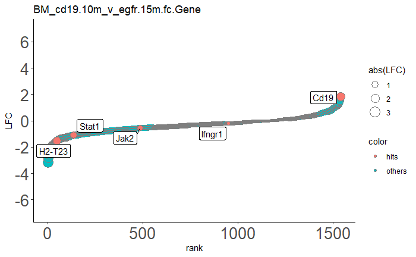

```r
BM_cd19.10m_v_egfr.15m.fc.Gene.plot
```

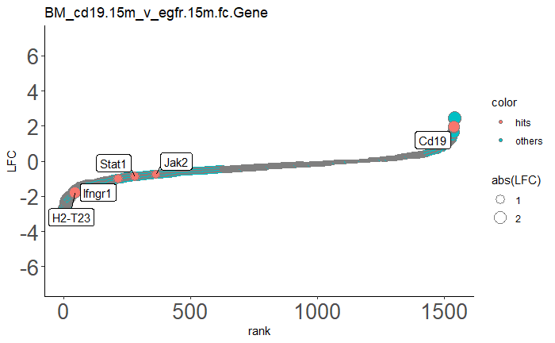

```r
BM_cd19.15m_v_egfr.15m.fc.Gene.plot
```

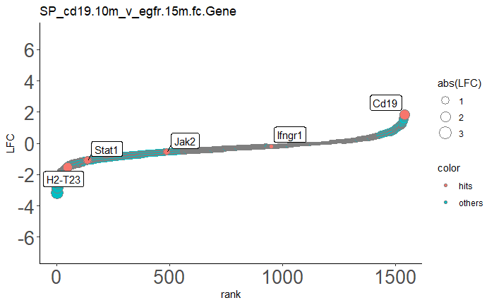

```r
SP_cd19.10m_v_egfr.15m.fc.Gene.plot
```

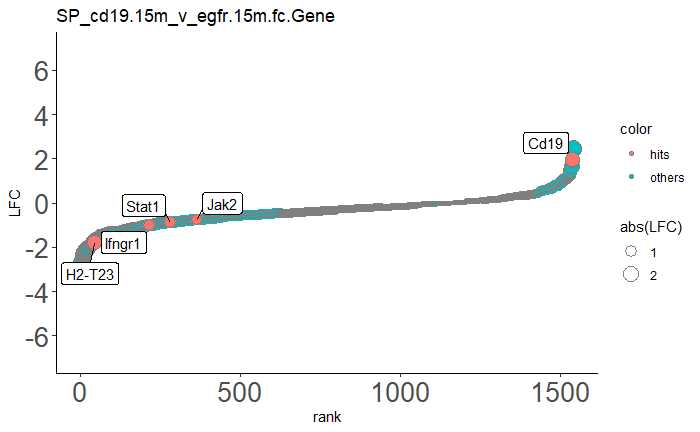

```r
SP_cd19.15m_v_egfr.15m.fc.Gene.plot
```

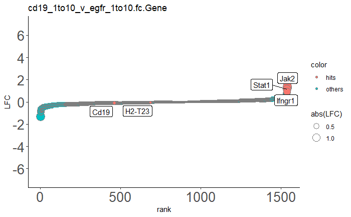

```r
cd19_1to10_v_egfr_1to10.fc.Gene.plot
```

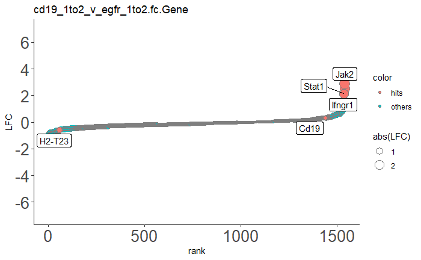

```r
cd19_1to2_v_egfr_1to2.fc.Gene.plot
```

```r
sorted_df <- GeneMeans %>% dplyr::select(cd19_1to2_v_egfr_1to2.fc.Gene,Gene) %>% arrange(cd19_1to2_v_egfr_1to2.fc.Gene)
sorted_df$rank <- c(1:nrow(sorted_df))
colnames(sorted_df) <- c("LFC","gene","rank")
sorted_df_top <- sorted_df[sorted_df$rank <= 10 | sorted_df$rank >= (nrow(sorted_df)-9),]
sorted_df$color <- "others"
sorted_df$color[match(c('Jak2','Stat1','Ifngr1','H2-T23','Cd19'),sorted_df$gene)] <- "hits"
df_to_highlight <- sorted_df[match(c('Jak2','Stat1','Ifngr1','H2-T23','Cd19'),sorted_df$gene),]

p1 <- ggplot(sorted_df, aes(x=rank, y=LFC)) +
  geom_point(aes(size=abs(LFC), fill = color),shape=21, color='grey50') +
  theme_bw() +
  geom_point(data = df_to_highlight, aes(size=abs(LFC), fill = color),shape=21, color='grey50') +
  theme(panel.border = element_blank(), panel.grid.major = element_blank(),
        panel.grid.minor = element_blank(), axis.line = element_line(colour = "black")) +
  theme(axis.text=element_text(size=20)) + ggtitle("cd19_1to2_v_egfr_1to2") +
  scale_y_continuous(breaks=seq(-6,6,2), limits=c(-7,7))


sorted_df <- GeneMeans %>% dplyr::select(cd19_1to10_v_egfr_1to10.fc.Gene,Gene) %>% arrange(cd19_1to10_v_egfr_1to10.fc.Gene)
sorted_df$rank <- c(1:nrow(sorted_df))
colnames(sorted_df) <- c("LFC","gene","rank")
sorted_df_top <- sorted_df[sorted_df$rank <= 10 | sorted_df$rank >= (nrow(sorted_df)-9),]
sorted_df$color <- "others"
sorted_df$color[match(c('Jak2','Stat1','Ifngr1','H2-T23','Cd19'),sorted_df$gene)] <- "hits"
df_to_highlight <- sorted_df[match(c('Jak2','Stat1','Ifngr1','H2-T23','Cd19'),sorted_df$gene),]

p2 <- ggplot(sorted_df, aes(x=rank, y=LFC)) +
  geom_point(aes(size=abs(LFC), fill = color),shape=21, color='grey50') +
  theme_bw() +
  geom_point(data = df_to_highlight, aes(size=abs(LFC), fill = color),shape=21, color='grey50') +
  theme(panel.border = element_blank(), panel.grid.major = element_blank(),
        panel.grid.minor = element_blank(), axis.line = element_line(colour = "black")) +
  theme(axis.text=element_text(size=20)) + ggtitle("cd19_1to10_v_egfr_1to10") +
  scale_y_continuous(breaks=seq(-6,6,2), limits=c(-7,7))
```

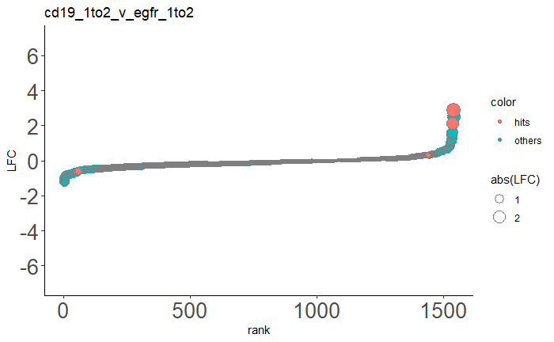

```r
p1
```

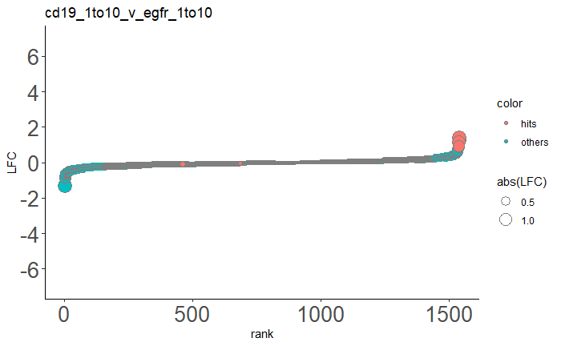

```r
p2
```

# Importing normalized input data for KA experiments, l2 transform

```r
all.n <- read.table("batch.normalized.txt", row.names = 1, sep = "\t", header = TRUE)
```

## Log2 normalization with plus 1 offset

```r
all.n <- all.n %>% dplyr::select(-Gene)
all.n.l2 <- log((all.n+1),2)

colnames(all.n.l2)<-paste(colnames(all.n.l2),"l2",sep=".")
```

## PCA plots

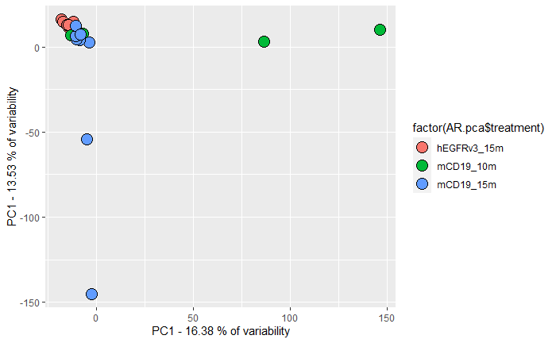

```r
#exclude.pattern <- c('pDNA','KA')
cols <- grep('^AR', colnames(all.n.l2))
AR.pca <- prcomp(t(all.n.l2[cols]))

var <- AR.pca$sdev^2
variance <- var/sum(var)
percentVar <- AR.pca$sdev^2 / sum(AR.pca$sdev^2 )
percentVar <- round(100 * percentVar,2)
AR.pca$percentVar <- percentVar
AR.samps <- read_xlsx("AR_conditions.xlsx")
AR.pca$treatment <-AR.samps$treatment
AR.pca$tissue <-AR.samps$tissue

arPCAplot <- ggplot(as.data.frame(AR.pca$x), aes(x=PC1, y=PC2)) +
  geom_point(aes(fill = factor(AR.pca$treatment)),shape=21, size = 5) +
  xlab("PC1 - 16.38 % of variability") +
  ylab("PC1 - 13.53 % of variability")

arPCAplot
```

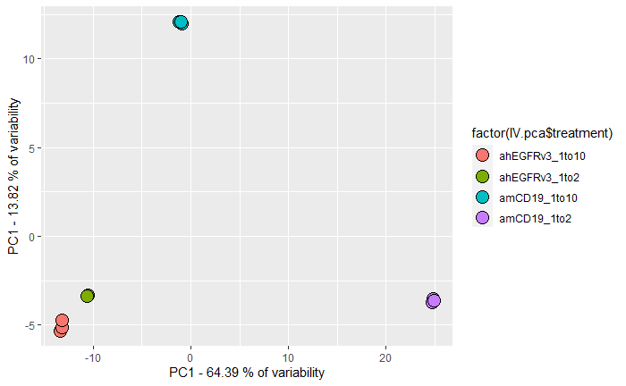

```r
ar.pca.data <- as.data.frame(AR.pca$x)
ar.pca.data$percentVar <- AR.pca$percentVar
ar.pca.data$treatment <- AR.pca$treatment
write.xlsx(ar.pca.data, file="AR.pca.xlsx", row.names=TRUE)
cols <- grep("^ah|^am", colnames(all.n.l2))
IV.pca <- prcomp(t(all.n.l2[cols]))

var <- IV.pca$sdev^2
variance <- var/sum(var)
percentVar <- IV.pca$sdev^2 / sum(IV.pca$sdev^2 )
percentVar <- round(100 * percentVar,2)
IV.pca$percentVar <- percentVar
IV.samps <- read_xlsx("IV_conditions.xlsx")
IV.pca$treatment <- IV.samps$treatment

ivPCAplot <- ggplot(as.data.frame(IV.pca$x), aes(x=PC1, y=PC2)) +
  geom_point(aes(fill = factor(IV.pca$treatment)),shape=21, size = 5) +
  xlab("PC1 - 64.39 % of variability") +
  ylab("PC1 - 13.82 % of variability")

ivPCAplot
```

```r
cols <- grep('^AR', colnames(all.n.l2))
cols2 <- cols[-c(13,14,19,20)]
ARsubset.pca <- prcomp(t(all.n.l2[cols2]))

var <- ARsubset.pca$sdev^2
variance <- var/sum(var)
percentVar <- ARsubset.pca$sdev^2 / sum(ARsubset.pca$sdev^2 )
percentVar <- round(100 * percentVar,2)
ARsubset.pca$percentVar <- percentVar
ARsubset.samps <- read_xlsx("AR_conditions2.xlsx")
ARsubset.pca$treatment <-ARsubset.samps$treatment
ARsubset.pca$tissue <-ARsubset.samps$tissue
ARsubset.pca$tiss.treat <- paste0(ARsubset.samps$tissue,".",ARsubset.samps$treatment)

arPCAplot <- ggplot(as.data.frame(ARsubset.pca$x), aes(x=PC1, y=PC2)) +
  geom_point(aes(fill = factor(ARsubset.pca$tiss.treat)),shape=21, size = 5) +
  xlab("PC1 - 11.73 % of variability") +
  ylab("PC1 - 10.03 % of variability")

arPCAplot

pdf('PCA_BM_and_SP_set_guideLevel.pdf',width=10, height=8)
```

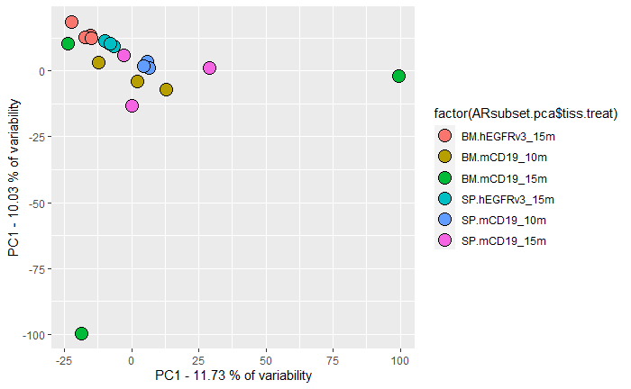

```r
print(arPCAplot)
dev.off()
```

## PCA for revision - 9/4/22 request

Guide-level plot for requested samples

```r
cols <- grep('^AR', colnames(all.n.l2))
cols3 <- cols[c(2,4,6,8,10,12,14,16)]
testAR <- all.n.l2[cols3]
ARsubset3.pca <- prcomp(t(all.n.l2[cols3]))

var <- ARsubset3.pca$sdev^2
variance <- var/sum(var)
percentVar <- ARsubset3.pca$sdev^2 / sum(ARsubset3.pca$sdev^2 )
percentVar <- round(100 * percentVar,2)
ARsubset3.pca$percentVar <- percentVar
ARsubset3.samps <- read_xlsx("AR_conditions3.xlsx")
ARsubset3.pca$treatment <-ARsubset3.samps$treatment
ARsubset3.pca$tissue <-ARsubset3.samps$tissue

write.xlsx(as.data.frame(ARsubset3.pca$x), file="SP_subset_PCA.xlsx", rowNames=TRUE)

arPCAplot3 <- ggplot(as.data.frame(ARsubset3.pca$x), aes(x=PC1, y=PC2)) +
  geom_point(aes(fill = factor(ARsubset3.pca$treatment)),shape=21, size = 5) +
  xlab("PC1 - 53.11 % of variability") +
  ylab("PC1 - 16.88 % of variability")

arPCAplot3

pdf('PCA_SPset_guideLevel.pdf',width=10, height=8)
```

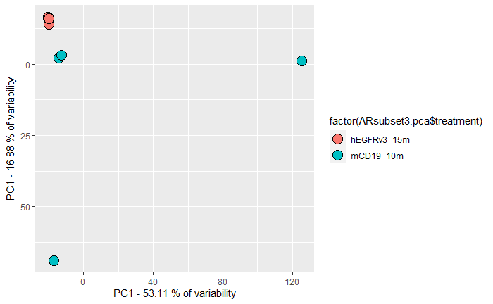

```r
print(arPCAplot3)
dev.off()
```

## gene-level PCA for revision - 9/6/22 request

Gene-level plots for requested samples

```r
gene.l2 <- read.xlsx("geneLevel_l2n_for_PCA.xlsx")
#gene.l2 <- gene.l2 %>% dplyr::filter(is.na(ControlGroup))
cols <- grep('^Avg.AR', colnames(gene.l2))
cols3 <- cols[c(2,4,6,8,10,12,14,16)]
#geneAR <- gene.l2[cols]
ARgene.pca <- prcomp(t(gene.l2[cols3]))

var <- ARgene.pca$sdev^2
variance <- var/sum(var)
percentVar <- ARgene.pca$sdev^2 / sum(ARgene.pca$sdev^2 )
percentVar <- round(100 * percentVar,2)
ARgene.pca$percentVar <- percentVar
ARgene.pca.samps <- read_xlsx("AR_conditions.xlsx")
ARgeneSubset.pca.samps <- read_xlsx("AR_conditions3.xlsx")
ARgene.pca$treatment <- ARgeneSubset.pca.samps$treatment
ARgene.pca$tissue <-ARgeneSubset.pca.samps$tissue

#write.xlsx(as.data.frame(ARgene.pca$x), file="ARgene_PCA.xlsx", rowNames=TRUE)

arPCAplot4 <- ggplot(as.data.frame(ARgene.pca$x), aes(x=PC1, y=PC2)) +
  geom_point(aes(fill = factor(ARgene.pca$treatment)),shape=21, size = 5) +
  xlab(paste0("PC1 - ",ARgene.pca$percentVar[1]," % of variability")) +
  ylab(paste0("PC2 - ",ARgene.pca$percentVar[2]," % of variability"))

arPCAplot4

pdf('PCA_geneLevel.pdf',width=10, height=8)
```

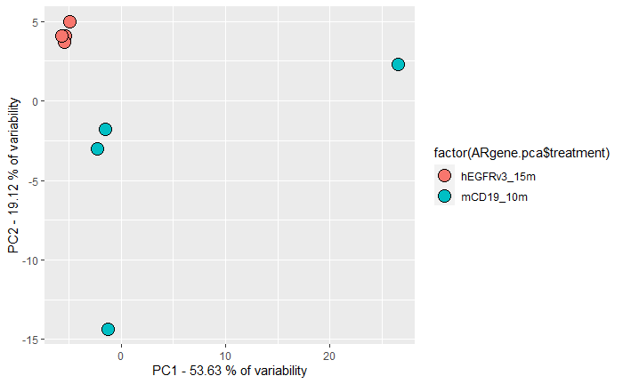

```r
print(arPCAplot4)
dev.off()
```

## Write normalized data

```r
all.counts <- read.xlsx("stockCounts.xlsx")
all.counts <- all.counts %>% dplyr::select(-Gene)
rownames(all.counts) <- all.counts[,1]
all.counts <- all.counts %>% dplyr::select(-sgRNA)
all.ct.l2 <- merge(x=all.counts,y=all.n.l2, by=0, all=TRUE, row.names=Row.names, Row.names=NULL)
#all.ct.l2 <- tibble::rownames_to_column(all.ct.l2, "sgRNA")
#write.xlsx(all.ct.l2, file="all.ct.l2.xlsx", overwrite = TRUE, rowNames=TRUE)
```

## additional sample stats

Count up numbers of guides with > 30 counts

```r
for(i in 1:ncol(all.counts)) {
  nn <- colnames(all.counts[i])
  n30 <- sum(all.counts[,i] > 30)
  print(paste(nn,n30))
}
```

```
[1] "KA1.RPMI_5 6134"
[1] "KA2.RPMI_5 6045"
[1] "KA3.RPMI_5 5975"
[1] "KA4.MPM_5 6167"
[1] "KA5.MPM_5 6161"
[1] "KA6.MPM_5 6180"
[1] "KA7.RPMI_21 6181"
[1] "KA8.RPMI_21 6161"
[1] "KA9.RPMI_21 6176"
[1] "KA10.MPM_21 6182"
[1] "KA11.MPM_21 6175"
[1] "KA12.MPM_21 6180"
[1] "AR2466_BM 6020"
[1] "AR2466_SP 6140"
[1] "AR2467_BM 6002"
```

[output cut: 43 more lines]

# QC bolxplots

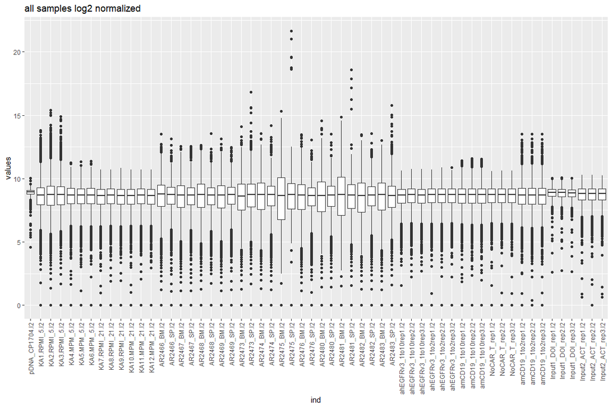

```r
ggplot(stack(all.n.l2), aes(x = ind, y = values)) + geom_boxplot() +
  theme(axis.text.x = element_text(angle = 90, vjust = 0.5, hjust=1)) + ggtitle("all samples log2 normalized")
```

## get some QC stats

```r
all.iqr <- as.data.frame(sapply(all.n.l2, IQR))
all.med <- as.data.frame(sapply(all.n.l2, median))
all.0 <- as.data.frame(colSums(all.n.l2 == 0))
all.stats <- cbind(all.0,all.med,all.iqr)

write.xlsx(all.stats, file="all.stats.xlsx", overwrite = TRUE, rowNames=TRUE)
```

## Calculate group averages

not applicable for this experiment

```r
# p12.Means <- p12.all.l2 %>% mutate(input.mean = select(., contains("input")) %>% rowMeans(na.rm = TRUE))
# p12.Means <- p12.Means %>% mutate(egfr.mean = select(., contains("egfr")) %>% rowMeans(na.rm = TRUE))
# p12.Means <- p12.Means %>% mutate(cd19.mean = select(., contains("cd19")) %>% rowMeans(na.rm = TRUE))
# p12.Means <- p12.Means %>% select(contains("mean"))
# write.xlsx(p12.Means, file="p12.Means.xlsx", overwrite = TRUE, rowNames=TRUE)
```

# Importing mageck test data and making plots

## MPM_21_v_RPMI_21

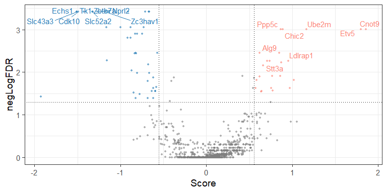

```r
MPM_21_v_RPMI_21.gdata <- ReadRRA("MPM_21_v_RPMI_21.gene_summary.txt", score = c("lfc", "rra")[1])
MPM_21_v_RPMI_21.sdata <- ReadsgRRA("MPM_21_v_RPMI_21.sgrna_summary.txt")

MPM_21_v_RPMI_21.gdata$negLogFDR = -log10(MPM_21_v_RPMI_21.gdata$FDR)
ScatterView(MPM_21_v_RPMI_21.gdata, x = "Score", y = "negLogFDR",
            label = "id", model = "volcano", top = 8,
            display_cut = TRUE, max.overlaps = Inf)
```

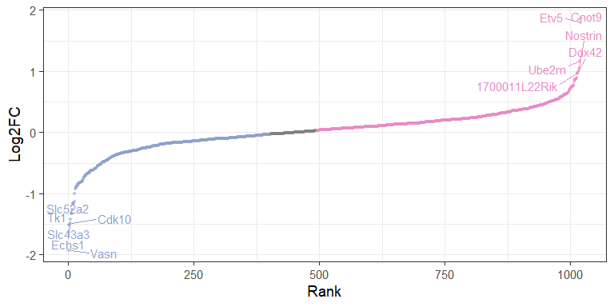

```r
MPM_21_v_RPMI_21.gdata$Rank = rank(MPM_21_v_RPMI_21.gdata$Score)
ScatterView(MPM_21_v_RPMI_21.gdata, x = "Rank", y = "Score", label = "id",
                 top = 6, auto_cut_y = TRUE, ylab = "Log2FC",
                 groups = c("top", "bottom"), max.overlaps = Inf)
```

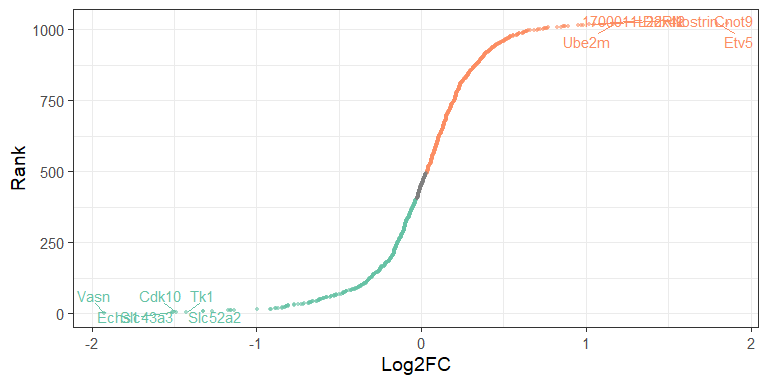

```r
ScatterView(MPM_21_v_RPMI_21.gdata, x = "Score", y = "Rank", label = "id",
            auto_cut_x = TRUE, groups = c("left", "right"),
            xlab = "Log2FC", top = 6, max.overlaps = Inf)
```

## MPM_5_v_RPMI_5

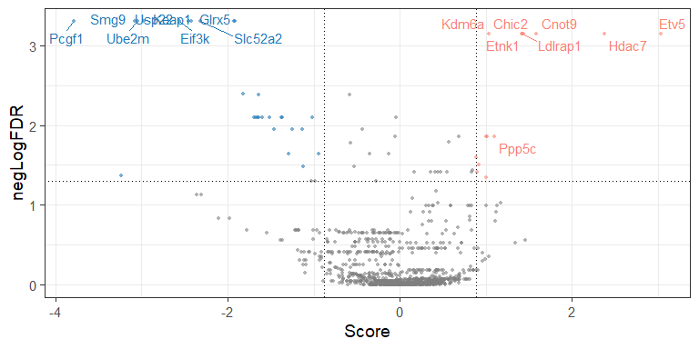

```r
MPM_5_v_RPMI_5.gdata <- ReadRRA("MPM_5_v_RPMI_5.gene_summary.txt", score = c("lfc", "rra")[1])
MPM_5_v_RPMI_5.sdata <- ReadsgRRA("MPM_5_v_RPMI_5.sgrna_summary.txt")

MPM_5_v_RPMI_5.gdata$negLogFDR = -log10(MPM_5_v_RPMI_5.gdata$FDR)
ScatterView(MPM_5_v_RPMI_5.gdata, x = "Score", y = "negLogFDR",
            label = "id", model = "volcano", top = 8,
            display_cut = TRUE, max.overlaps = Inf)
```

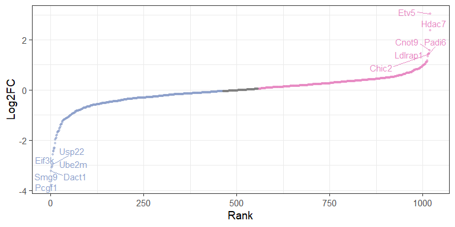

```r
MPM_5_v_RPMI_5.gdata$Rank = rank(MPM_5_v_RPMI_5.gdata$Score)
ScatterView(MPM_5_v_RPMI_5.gdata, x = "Rank", y = "Score", label = "id",
                 top = 6, auto_cut_y = TRUE, ylab = "Log2FC",
                 groups = c("top", "bottom"), max.overlaps = Inf)
```

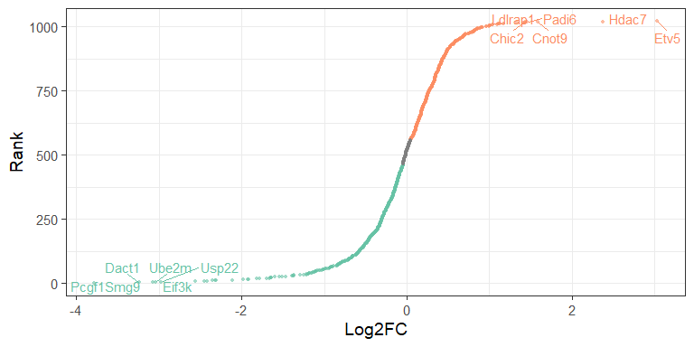

```r
ScatterView(MPM_5_v_RPMI_5.gdata, x = "Score", y = "Rank", label = "id",
            auto_cut_x = TRUE, groups = c("left", "right"),
            xlab = "Log2FC", top = 6, max.overlaps = Inf)
```

## RPMI_5_v_RPMI_21

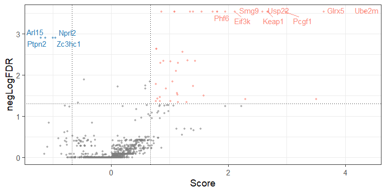

```r
RPMI_5_v_RPMI_21.gdata <- ReadRRA("RPMI_5_v_RPMI_21.gene_summary.txt", score = c("lfc", "rra")[1])
RPMI_5_v_RPMI_21.sdata <- ReadsgRRA("RPMI_5_v_RPMI_21.sgrna_summary.txt")

RPMI_5_v_RPMI_21.gdata$negLogFDR = -log10(RPMI_5_v_RPMI_21.gdata$FDR)
ScatterView(RPMI_5_v_RPMI_21.gdata, x = "Score", y = "negLogFDR",
            label = "id", model = "volcano", top = 8,
            display_cut = TRUE, max.overlaps = Inf)
```

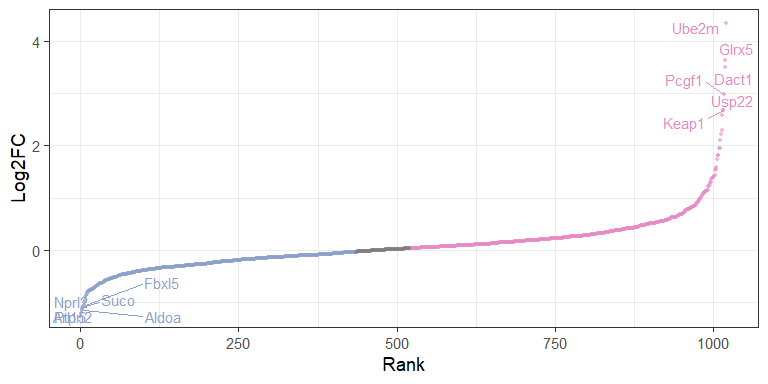

```r
RPMI_5_v_RPMI_21.gdata$Rank = rank(RPMI_5_v_RPMI_21.gdata$Score)
ScatterView(RPMI_5_v_RPMI_21.gdata, x = "Rank", y = "Score", label = "id",
                 top = 6, auto_cut_y = TRUE, ylab = "Log2FC",
                 groups = c("top", "bottom"), max.overlaps = Inf)
```

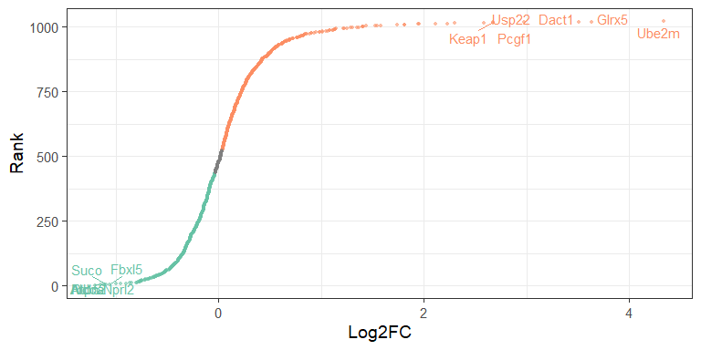

```r
ScatterView(RPMI_5_v_RPMI_21.gdata, x = "Score", y = "Rank", label = "id",
            auto_cut_x = TRUE, groups = c("left", "right"),
            xlab = "Log2FC", top = 6, max.overlaps = Inf)
```

## MPM_5_v_MPM_21

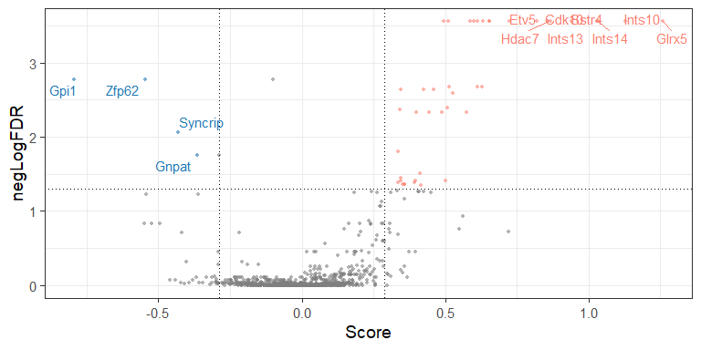

```r
MPM_5_v_MPM_21.gdata <- ReadRRA("MPM_5_v_MPM_21.gene_summary.txt", score = c("lfc", "rra")[1])
MPM_5_v_MPM_21.sdata <- ReadsgRRA("MPM_5_v_MPM_21.sgrna_summary.txt")

MPM_5_v_MPM_21.gdata$negLogFDR = -log10(MPM_5_v_MPM_21.gdata$FDR)
ScatterView(MPM_5_v_MPM_21.gdata, x = "Score", y = "negLogFDR",
            label = "id", model = "volcano", top = 8,
            display_cut = TRUE, max.overlaps = Inf)
```

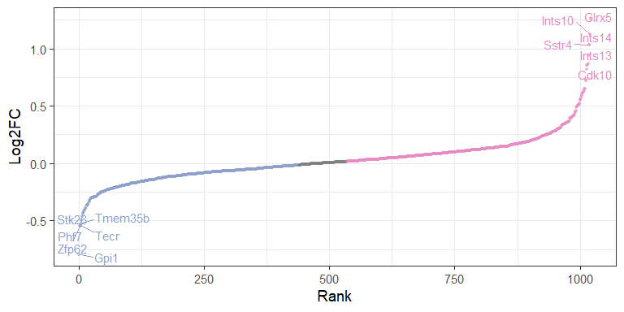

```r
MPM_5_v_MPM_21.gdata$Rank = rank(MPM_5_v_MPM_21.gdata$Score)
ScatterView(MPM_5_v_MPM_21.gdata, x = "Rank", y = "Score", label = "id",
                 top = 6, auto_cut_y = TRUE, ylab = "Log2FC",
                 groups = c("top", "bottom"), max.overlaps = Inf)
```

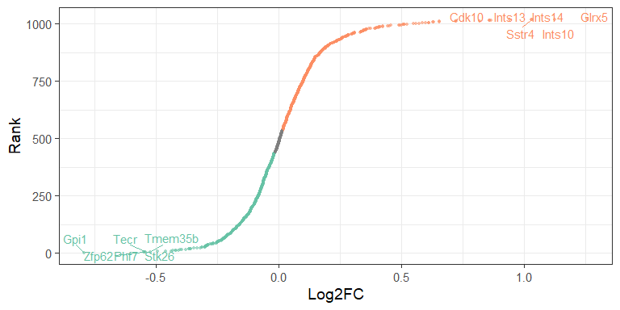

```r
ScatterView(MPM_5_v_MPM_21.gdata, x = "Score", y = "Rank", label = "id",
            auto_cut_x = TRUE, groups = c("left", "right"),
            xlab = "Log2FC", top = 6, max.overlaps = Inf)
```

## SP_cd19.10m_v_egfr.15m

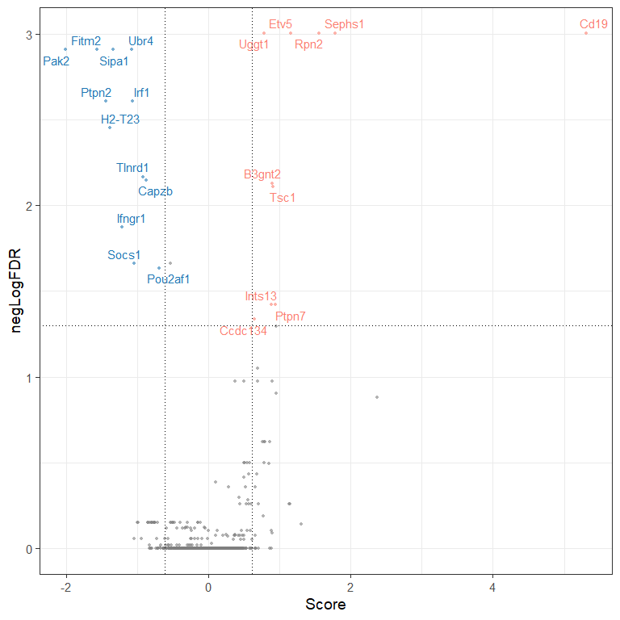

```r
SP_cd19.10m_v_egfr.15m.gdata <- ReadRRA("SP_cd19.10m_v_egfr.15m.gene_summary.txt", score = c("lfc", "rra")[1])
SP_cd19.10m_v_egfr.15m.sdata <- ReadsgRRA("SP_cd19.10m_v_egfr.15m.sgrna_summary.txt")

SP_cd19.10m_v_egfr.15m.gdata$negLogFDR = -log10(SP_cd19.10m_v_egfr.15m.gdata$FDR)
ScatterView(SP_cd19.10m_v_egfr.15m.gdata, x = "Score", y = "negLogFDR",
            label = "id", model = "volcano", top = 15,
            display_cut = TRUE, max.overlaps = Inf)
```

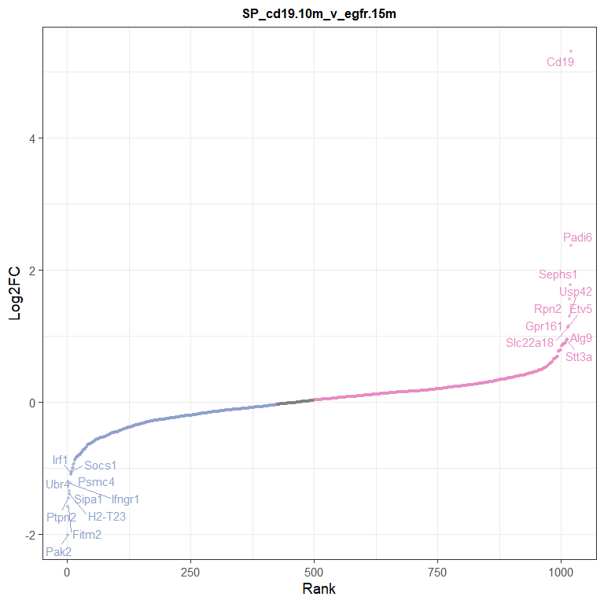

```r
SP_cd19.10m_v_egfr.15m.gdata$Rank = rank(SP_cd19.10m_v_egfr.15m.gdata$Score)
ScatterView(SP_cd19.10m_v_egfr.15m.gdata, x = "Rank", y = "Score", label = "id",
                 top = 10, auto_cut_y = TRUE, ylab = "Log2FC",
                 groups = c("top", "bottom"), max.overlaps = Inf) +
  ggtitle("SP_cd19.10m_v_egfr.15m") + theme(plot.title = element_text(size = 12, face = "bold"))
```

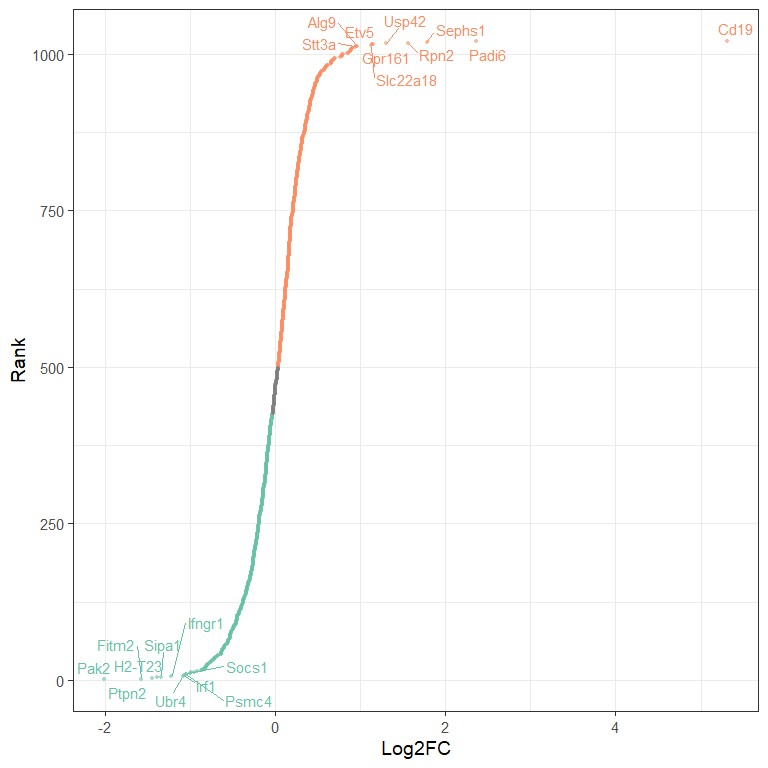

```r
ScatterView(SP_cd19.10m_v_egfr.15m.gdata, x = "Score", y = "Rank", label = "id",
            auto_cut_x = TRUE, groups = c("left", "right"),
            xlab = "Log2FC", top = 10, max.overlaps = Inf)
```

## SP_cd19.15m_v_egfr.15m

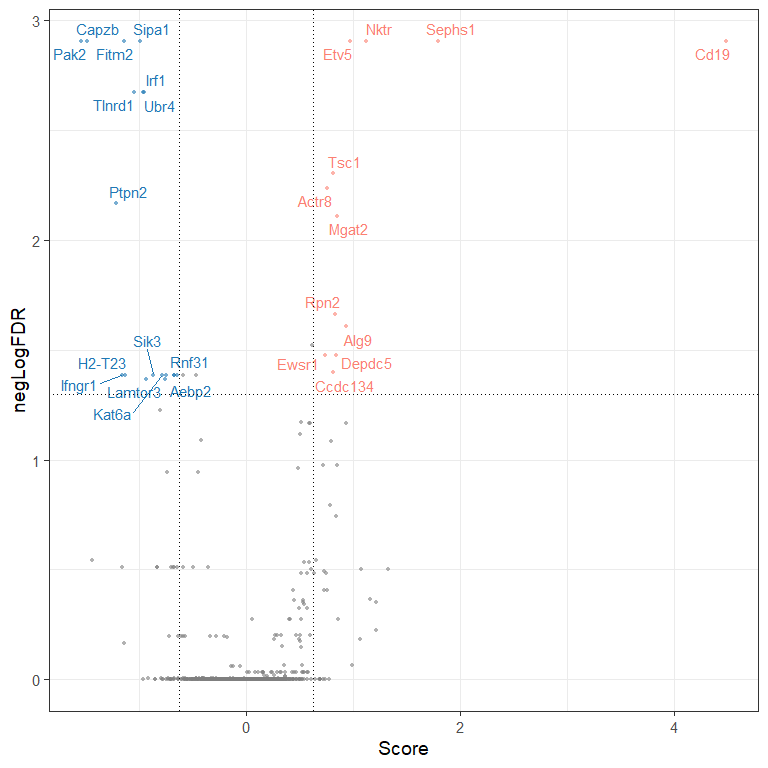

```r
SP_cd19.15m_v_egfr.15m.gdata <- ReadRRA("SP_cd19.15m_v_egfr.15m.gene_summary.txt", score = c("lfc", "rra")[1])
SP_cd19.15m_v_egfr.15m.sdata <- ReadsgRRA("SP_cd19.15m_v_egfr.15m.sgrna_summary.txt")

SP_cd19.15m_v_egfr.15m.gdata$negLogFDR = -log10(SP_cd19.15m_v_egfr.15m.gdata$FDR)
ScatterView(SP_cd19.15m_v_egfr.15m.gdata, x = "Score", y = "negLogFDR",
            label = "id", model = "volcano", top = 15,
            display_cut = TRUE, max.overlaps = Inf)
```

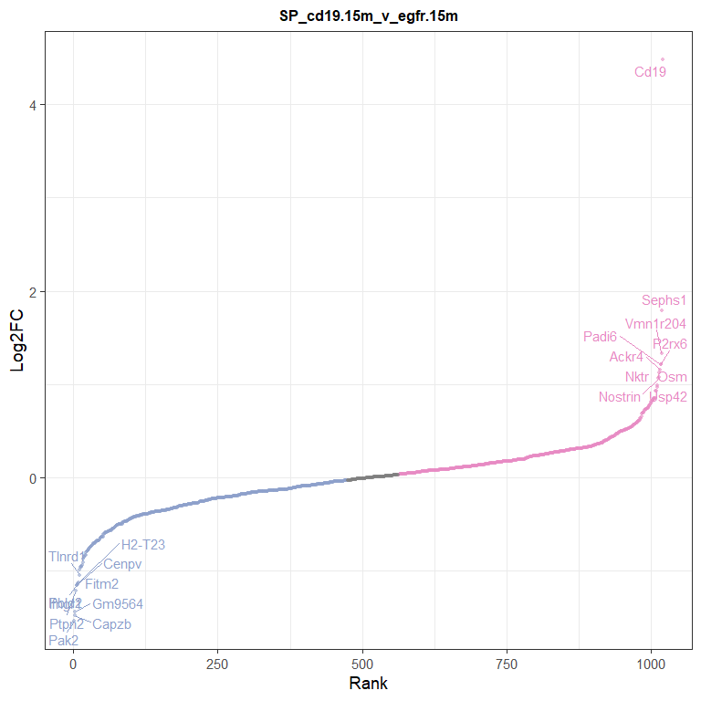

```r
SP_cd19.15m_v_egfr.15m.gdata$Rank = rank(SP_cd19.15m_v_egfr.15m.gdata$Score)
ScatterView(SP_cd19.15m_v_egfr.15m.gdata, x = "Rank", y = "Score", label = "id",
                 top = 10, auto_cut_y = TRUE, ylab = "Log2FC",
                 groups = c("top", "bottom"), max.overlaps = Inf) +
  ggtitle("SP_cd19.15m_v_egfr.15m") + theme(plot.title = element_text(size = 12, face = "bold"))
```

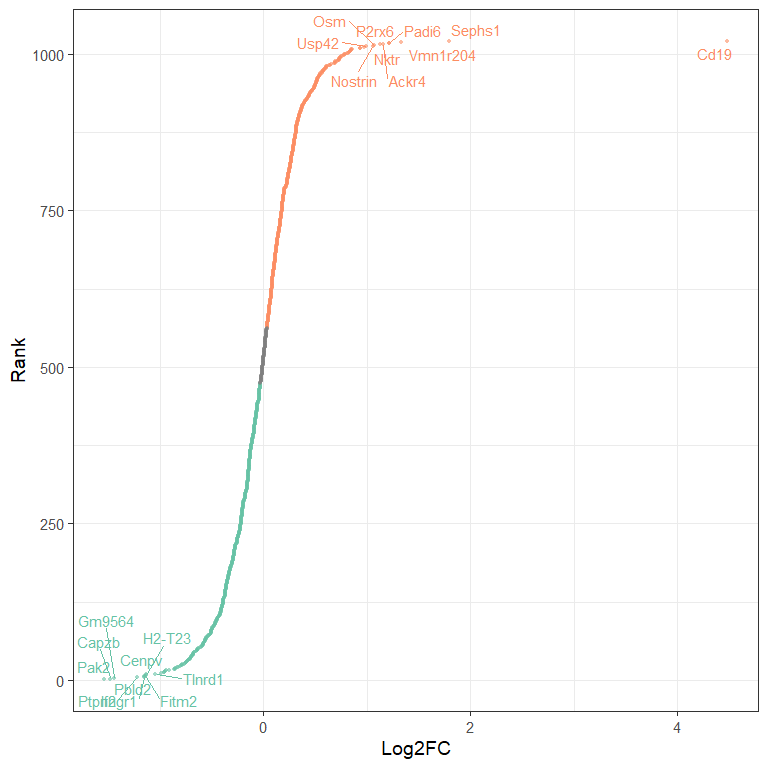

```r
ScatterView(SP_cd19.15m_v_egfr.15m.gdata, x = "Score", y = "Rank", label = "id",
            auto_cut_x = TRUE, groups = c("left", "right"),
            xlab = "Log2FC", top = 10, max.overlaps = Inf)
```

## BM_cd19.10m_v_egfr.15m

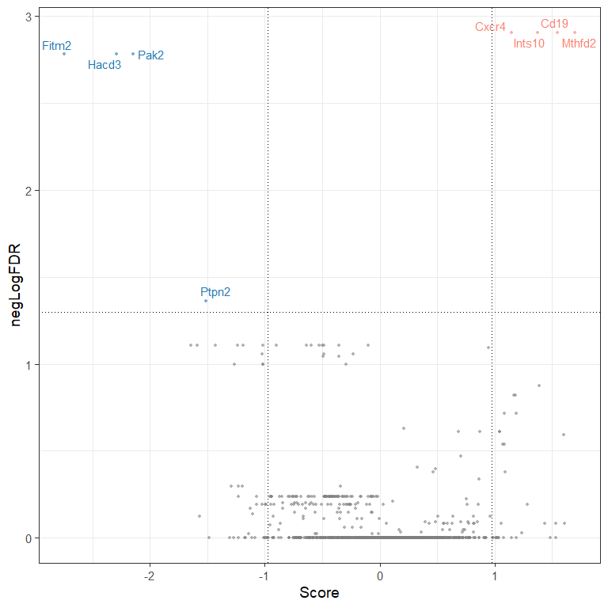

```r
BM_cd19.10m_v_egfr.15m.gdata <- ReadRRA("BM_cd19.10m_v_egfr.15m.gene_summary.txt", score = c("lfc", "rra")[1])
BM_cd19.10m_v_egfr.15m.sdata <- ReadsgRRA("BM_cd19.10m_v_egfr.15m.sgrna_summary.txt")

BM_cd19.10m_v_egfr.15m.gdata$negLogFDR = -log10(BM_cd19.10m_v_egfr.15m.gdata$FDR)
ScatterView(BM_cd19.10m_v_egfr.15m.gdata, x = "Score", y = "negLogFDR",
            label = "id", model = "volcano", top = 15,
            display_cut = TRUE, max.overlaps = Inf)
```

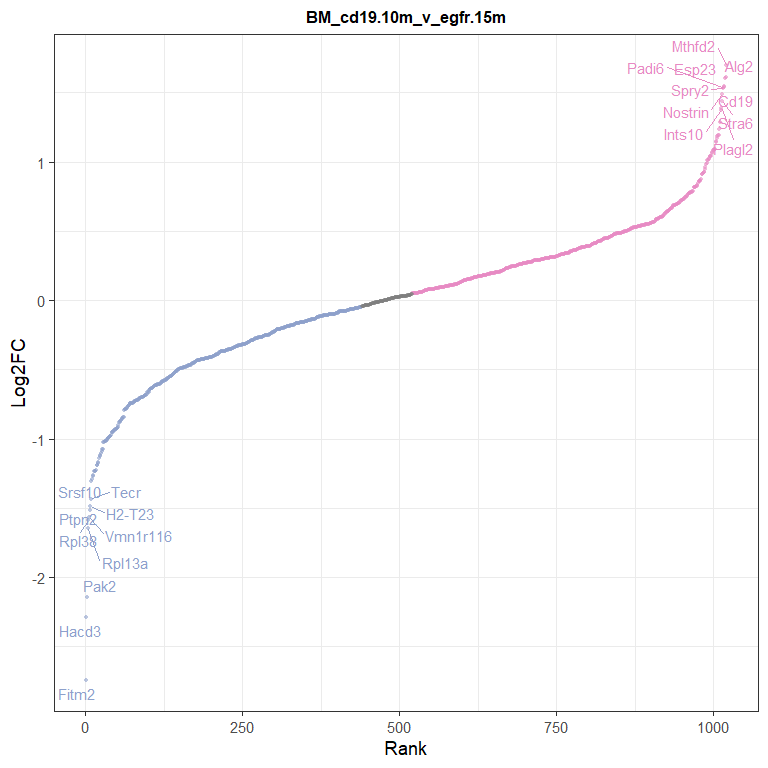

```r
BM_cd19.10m_v_egfr.15m.gdata$Rank = rank(BM_cd19.10m_v_egfr.15m.gdata$Score)
ScatterView(BM_cd19.10m_v_egfr.15m.gdata, x = "Rank", y = "Score", label = "id",
                 top = 10, auto_cut_y = TRUE, ylab = "Log2FC",
                 groups = c("top", "bottom"), max.overlaps = Inf) +
  ggtitle("BM_cd19.10m_v_egfr.15m") + theme(plot.title = element_text(size = 12, face = "bold"))
```

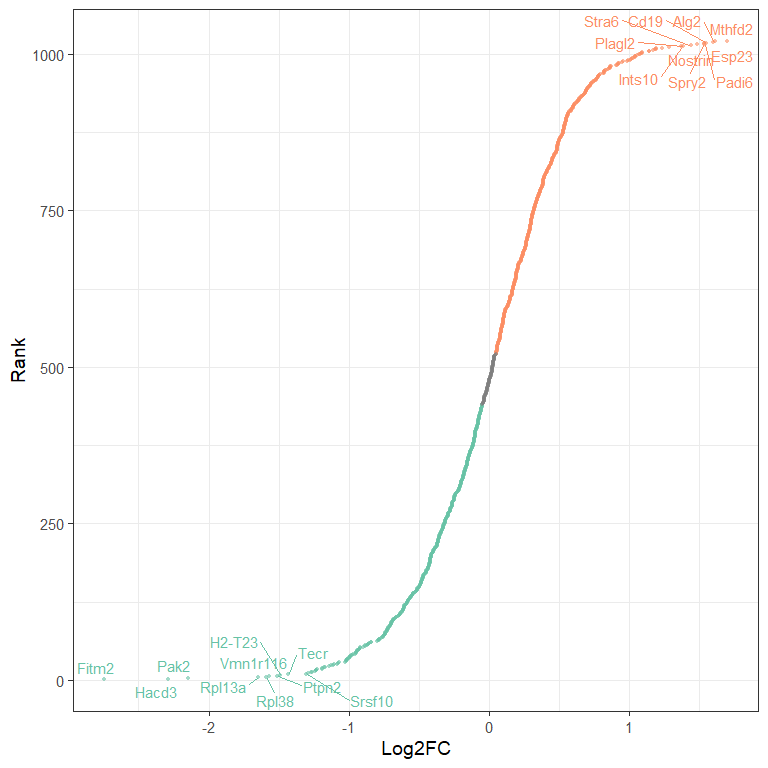

```r
ScatterView(BM_cd19.10m_v_egfr.15m.gdata, x = "Score", y = "Rank", label = "id",
            auto_cut_x = TRUE, groups = c("left", "right"),
            xlab = "Log2FC", top = 10, max.overlaps = Inf)
```

## BM_cd19.15m_v_egfr.15m

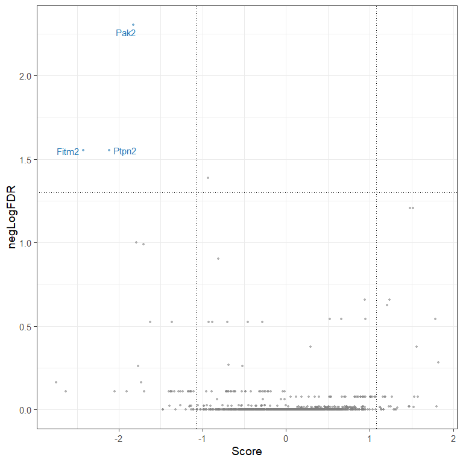

```r
BM_cd19.15m_v_egfr.15m.gdata <- ReadRRA("BM_cd19.15m_v_egfr.15m.gene_summary.txt", score = c("lfc", "rra")[1])
BM_cd19.15m_v_egfr.15m.sdata <- ReadsgRRA("BM_cd19.15m_v_egfr.15m.sgrna_summary.txt")

BM_cd19.15m_v_egfr.15m.gdata$negLogFDR = -log10(BM_cd19.15m_v_egfr.15m.gdata$FDR)
ScatterView(BM_cd19.15m_v_egfr.15m.gdata, x = "Score", y = "negLogFDR",
            label = "id", model = "volcano", top = 15,
            display_cut = TRUE, max.overlaps = Inf)
```

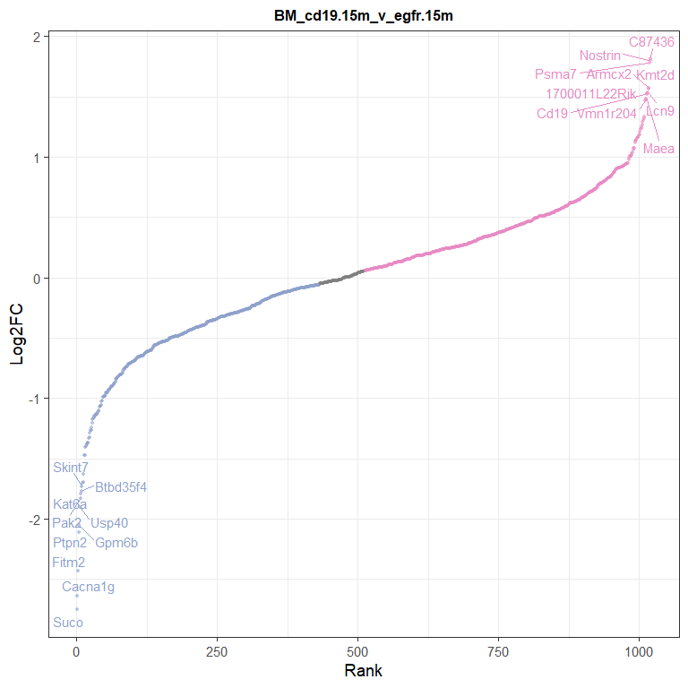

```r
BM_cd19.15m_v_egfr.15m.gdata$Rank = rank(BM_cd19.15m_v_egfr.15m.gdata$Score)
ScatterView(BM_cd19.15m_v_egfr.15m.gdata, x = "Rank", y = "Score", label = "id",
                 top = 10, auto_cut_y = TRUE, ylab = "Log2FC",
                 groups = c("top", "bottom"), max.overlaps = Inf) +
  ggtitle("BM_cd19.15m_v_egfr.15m") + theme(plot.title = element_text(size = 12, face = "bold"))
```

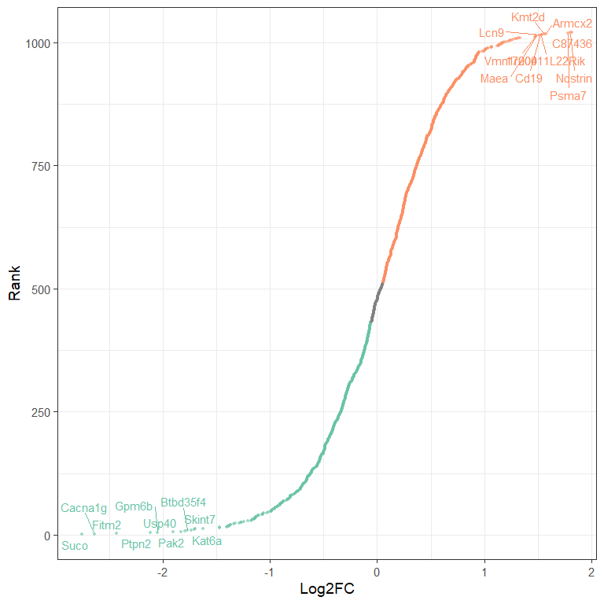

```r
ScatterView(BM_cd19.15m_v_egfr.15m.gdata, x = "Score", y = "Rank", label = "id",
            auto_cut_x = TRUE, groups = c("left", "right"),
            xlab = "Log2FC", top = 10, max.overlaps = Inf)
```

## cd19_1to2_v_egfr_1to2

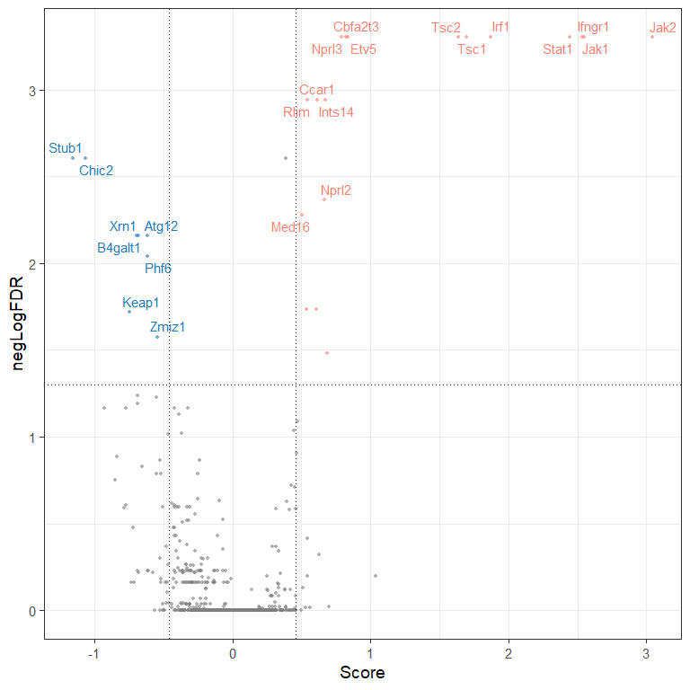

```r
cd19_1to2_v_egfr_1to2.gdata <- ReadRRA("cd19_1to2_v_egfr_1to2.gene_summary.txt", score = c("lfc", "rra")[1])
cd19_1to2_v_egfr_1to2.sdata <- ReadsgRRA("cd19_1to2_v_egfr_1to2.sgrna_summary.txt")

cd19_1to2_v_egfr_1to2.gdata$negLogFDR = -log10(cd19_1to2_v_egfr_1to2.gdata$FDR)
ScatterView(cd19_1to2_v_egfr_1to2.gdata, x = "Score", y = "negLogFDR",
            label = "id", model = "volcano", top = 15,
            display_cut = TRUE, max.overlaps = Inf)
```

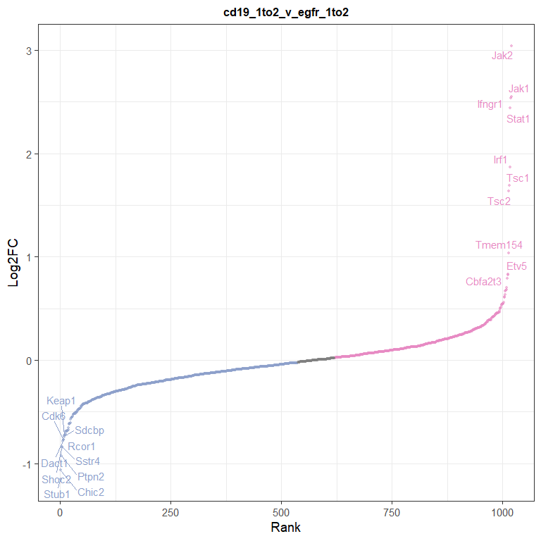

```r
cd19_1to2_v_egfr_1to2.gdata$Rank = rank(cd19_1to2_v_egfr_1to2.gdata$Score)
ScatterView(cd19_1to2_v_egfr_1to2.gdata, x = "Rank", y = "Score", label = "id",
                 top = 10, auto_cut_y = TRUE, ylab = "Log2FC",
                 groups = c("top", "bottom"), max.overlaps = Inf) +
  ggtitle("cd19_1to2_v_egfr_1to2") + theme(plot.title = element_text(size = 12, face = "bold"))
```

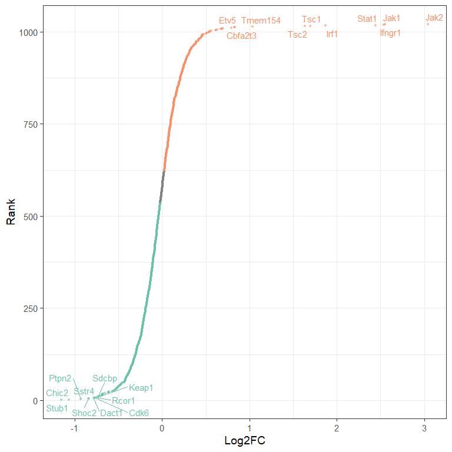

```r
ScatterView(cd19_1to2_v_egfr_1to2.gdata, x = "Score", y = "Rank", label = "id",
            auto_cut_x = TRUE, groups = c("left", "right"),
            xlab = "Log2FC", top = 10, max.overlaps = Inf)
```

## cd19_1to10_v_egfr_1to10

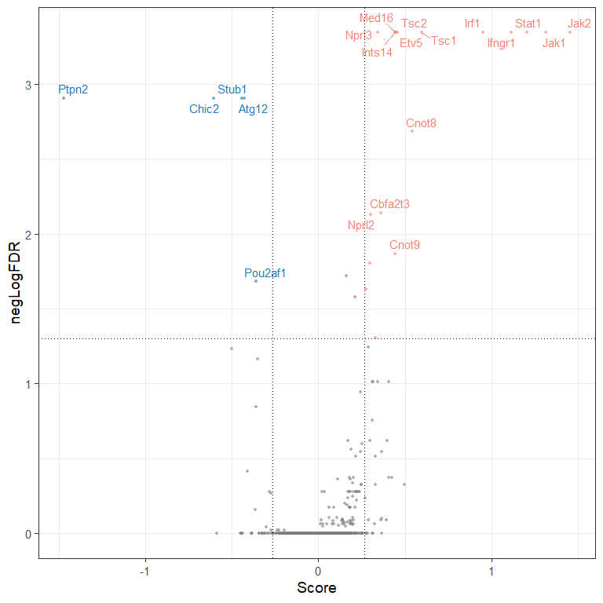

```r
cd19_1to10_v_egfr_1to10.gdata <- ReadRRA("cd19_1to10_v_egfr_1to10.gene_summary.txt", score = c("lfc", "rra")[1])
cd19_1to10_v_egfr_1to10.sdata <- ReadsgRRA("cd19_1to10_v_egfr_1to10.sgrna_summary.txt")

cd19_1to10_v_egfr_1to10.gdata$negLogFDR = -log10(cd19_1to10_v_egfr_1to10.gdata$FDR)
ScatterView(cd19_1to10_v_egfr_1to10.gdata, x = "Score", y = "negLogFDR",
            label = "id", model = "volcano", top = 15,
            display_cut = TRUE, max.overlaps = Inf)
```

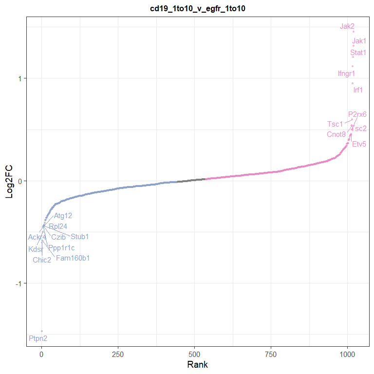

```r
cd19_1to10_v_egfr_1to10.gdata$Rank = rank(cd19_1to10_v_egfr_1to10.gdata$Score)
ScatterView(cd19_1to10_v_egfr_1to10.gdata, x = "Rank", y = "Score", label = "id",
                 top = 10, auto_cut_y = TRUE, ylab = "Log2FC",
                 groups = c("top", "bottom"), max.overlaps = Inf) +
  ggtitle("cd19_1to10_v_egfr_1to10") + theme(plot.title = element_text(size = 12, face = "bold"))
```

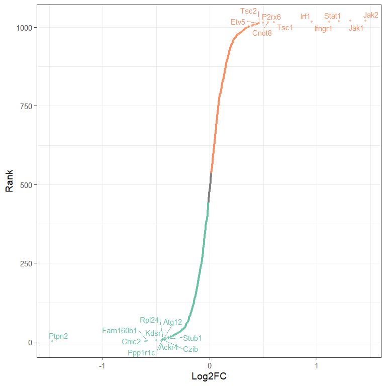

```r
ScatterView(cd19_1to10_v_egfr_1to10.gdata, x = "Score", y = "Rank", label = "id",
            auto_cut_x = TRUE, groups = c("left", "right"),
            xlab = "Log2FC", top = 10, max.overlaps = Inf)
```

## Fig2b

```r
#hits <- c("Jak1","Jak2","Stat1","Ifngr1","H2-T23","Cd19")

BM_cd19.10m_v_egfr.15m.gdata$Rank = rank(BM_cd19.10m_v_egfr.15m.gdata$Score)
#BM_cd19.10m_v_egfr.15m.gdata$absScore = abs(BM_cd19.10m_v_egfr.15m.gdata$Score)
#BM_cd19.10m_v_egfr.15m.gdata  <- BM_cd19.10m_v_egfr.15m.gdata %>% mutate(toHighlight = ifelse(id %in% hits, "highlight", "not"))
#BM_cd19.10m_v_egfr.15m.gdata$color[match(c('Jak2','Stat1','Ifngr1','H2-T23','Cd19'),BM_cd19.10m_v_egfr.15m.gdata$id)]
a <- ScatterView(BM_cd19.10m_v_egfr.15m.gdata, x = "Rank", y = "Score", label = "id",
                 toplabels = c("Jak1","Jak2","Stat1","Ifngr1","H2-T23","Cd19"), auto_cut_y = TRUE, ylab = "Log2 fold change",
                 groups = c("top", "bottom"), max.overlaps = Inf) + ylim(-6, 6) +
  ggtitle("BM_cd19.10m_v_egfr.15m") + theme(plot.title = element_text(size = 12, face = "bold"))

BM_cd19.15m_v_egfr.15m.gdata$Rank = rank(BM_cd19.15m_v_egfr.15m.gdata$Score)
b <- ScatterView(BM_cd19.15m_v_egfr.15m.gdata, x = "Rank", y = "Score", label = "id",
                 toplabels = c("Jak1","Jak2","Stat1","Ifngr1","H2-T23","Cd19"), auto_cut_y = TRUE, ylab = "Log2 fold change",
                 groups = c("top", "bottom"), max.overlaps = Inf) + ylim(-6, 6) +
  ggtitle("BM_cd19.15m_v_egfr.15m") + theme(plot.title = element_text(size = 12, face = "bold"))

SP_cd19.10m_v_egfr.15m.gdata$Rank = rank(SP_cd19.10m_v_egfr.15m.gdata$Score)
c <- ScatterView(SP_cd19.10m_v_egfr.15m.gdata, x = "Rank", y = "Score", label = "id",
                 toplabels = c("Jak1","Jak2","Stat1","Ifngr1","H2-T23","Cd19"), auto_cut_y = TRUE, ylab = "Log2 fold change",
                 groups = c("top", "bottom"), max.overlaps = Inf) + ylim(-6, 6) +
  ggtitle("SP_cd19.10m_v_egfr.15m") + theme(plot.title = element_text(size = 12, face = "bold"))

SP_cd19.15m_v_egfr.15m.gdata$Rank = rank(SP_cd19.15m_v_egfr.15m.gdata$Score)
d <- ScatterView(SP_cd19.15m_v_egfr.15m.gdata, x = "Rank", y = "Score", label = "id",
                 toplabels = c("Jak1","Jak2","Stat1","Ifngr1","H2-T23","Cd19"), auto_cut_y = TRUE, ylab = "Log2 fold change",
                 groups = c("top", "bottom"), max.overlaps = Inf) + ylim(-6, 6) +
  ggtitle("SP_cd19.15m_v_egfr.15m") + theme(plot.title = element_text(size = 12, face = "bold"))

cd19_1to2_v_egfr_1to2.gdata$Rank = rank(cd19_1to2_v_egfr_1to2.gdata$Score)
e <- ScatterView(cd19_1to2_v_egfr_1to2.gdata, x = "Rank", y = "Score", label = "id",
                 toplabels = c("Jak1","Jak2","Stat1","Ifngr1","H2-T23","Cd19"), auto_cut_y = TRUE, ylab = "Log2 fold change",
                 groups = c("top", "bottom"), max.overlaps = Inf) + ylim(-6, 6) +
  ggtitle("cd19_1to2_v_egfr_1to2") + theme(plot.title = element_text(size = 12, face = "bold"))

cd19_1to10_v_egfr_1to10.gdata$Rank = rank(cd19_1to10_v_egfr_1to10.gdata$Score)
f <- ScatterView(cd19_1to10_v_egfr_1to10.gdata, x = "Rank", y = "Score", label = "id",
                 toplabels = c("Jak1","Jak2","Stat1","Ifngr1","H2-T23","Cd19"), auto_cut_y = TRUE, ylab = "Log2 fold change",
                 groups = c("top", "bottom"), max.overlaps = Inf) + ylim(-6, 6) +
  ggtitle("cd19_1to10_v_egfr_1to10") + theme(plot.title = element_text(size = 12, face = "bold"))
```

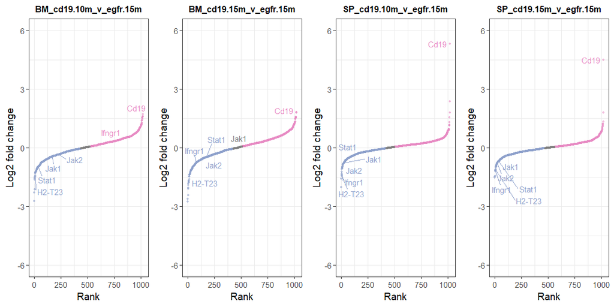

```r
ggarrange(a,b,c,d, ncol=4, nrow=1)
```

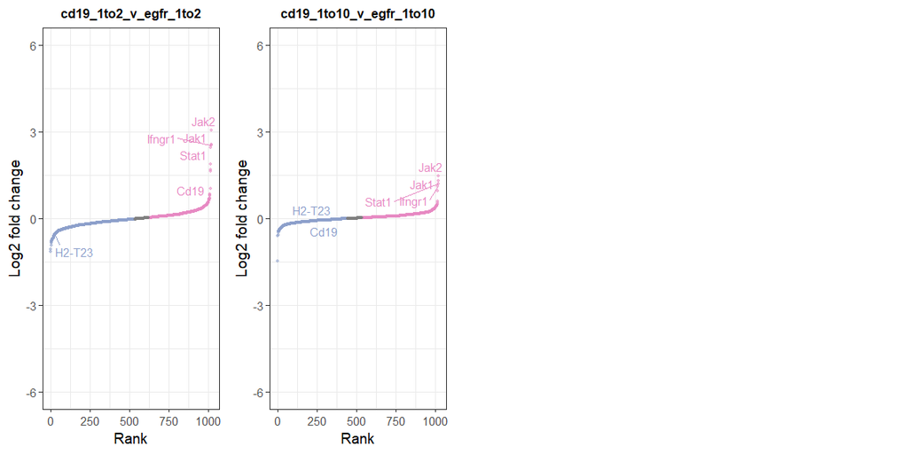

```r
ggarrange(e,f, ncol=4, nrow=1)
```

# trying to make plots

## Assembling mageck gene-level fold changes

```r
SP.10m <- SP_cd19.10m_v_egfr.15m.gdata
colnames(SP.10m) <- c("id","SP.10m.Score","SP.10m.FDR","SP.10m.negLogFDR","SP.10m.Rank")
SP.15m <- SP_cd19.15m_v_egfr.15m.gdata
colnames(SP.15m) <- c("id","SP.15m.Score","SP.15m.FDR","SP.15m.negLogFDR","SP.15m.Rank")
BM.10m <- BM_cd19.10m_v_egfr.15m.gdata
colnames(BM.10m) <- c("id","BM.10m.Score","BM.10m.FDR","BM.10m.negLogFDR","BM.10m.Rank")
BM.15m <- BM_cd19.15m_v_egfr.15m.gdata
colnames(BM.15m) <- c("id","BM.15m.Score","BM.15m.FDR","BM.15m.negLogFDR","BM.15m.Rank")
ET.1.2 <- cd19_1to2_v_egfr_1to2.gdata
colnames(ET.1.2) <- c("id","ET.1.2.Score","ET.1.2.FDR","ET.1.2.negLogFDR","ET.1.2.Rank")
ET.1.10 <- cd19_1to10_v_egfr_1to10.gdata
colnames(ET.1.10) <- c("id","ET.1.10.Score","ET.1.10.FDR","ET.1.10.negLogFDR","ET.1.10.Rank")

Mageck.combined <- merge(x=SP.10m, y=SP.15m, by.x=c("id"),by.y=c("id"), all=TRUE)
Mageck.combined <- merge(x=Mageck.combined,y=BM.10m, by.x=c("id"),by.y=c("id"), all=TRUE)
Mageck.combined <- merge(x=Mageck.combined,y=BM.15m, by.x=c("id"),by.y=c("id"), all=TRUE)
Mageck.combined <- merge(x=Mageck.combined,y=ET.1.2, by.x=c("id"),by.y=c("id"), all=TRUE)
Mageck.combined <- merge(x=Mageck.combined,y=ET.1.10, by.x=c("id"),by.y=c("id"), all=TRUE)
```

## testing

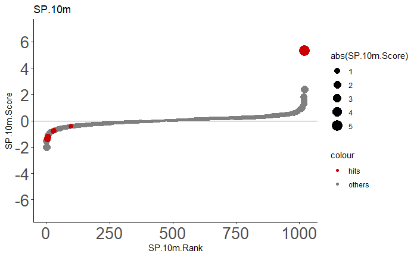

```r
sorted_df <- SP.10m %>% dplyr::arrange(SP.10m.Rank)
sorted_df <- sorted_df %>% mutate(top = if_else(sorted_df$SP.10m.Rank <= 10 | sorted_df$SP.10m.Rank >= (nrow(sorted_df)-9),"top","rest"))
sorted_df$color <- "others"
sorted_df$color[match(c("Jak1","Jak2","Stat1","Ifngr1","H2-T23","Cd19"),sorted_df$id)] <- "hits"
df_to_highlight <- sorted_df[match(c("Jak1","Jak2","Stat1","Ifngr1","H2-T23","Cd19"),sorted_df$id),]

ggplot(sorted_df, aes(x=SP.10m.Rank, y=SP.10m.Score)) + geom_point(aes(size=abs(SP.10m.Score), color = "grey50")) +
  geom_point(data=df_to_highlight, aes(size=abs(df_to_highlight$SP.10m.Score), color=color)) +
  scale_color_manual(values = c("hits" = "#CC0000", "others" = "grey50")) +
  theme_bw() +
#  geom_text_repel(data=df_to_highlight, aes(label = id), min.segment.length = 0) +
  theme(panel.border = element_blank(), panel.grid.major = element_blank(), panel.grid.minor = element_blank(), axis.line = element_line(colour = "black")) +
  theme(axis.text=element_text(size=20)) +
  ggtitle("SP.10m") +
  scale_y_continuous(breaks=seq(-6,6,2), limits=c(-7,7)) + geom_hline(yintercept=0, color="grey50")
```

## First version

```r
#Scorecolumns <- c("SP.10m.Score")
#Scorecolumns <- c("SP.10m.Score","SP.15m.Score","BM.10m.Score","BM.15m.Score","ET.1.2.Score","ET.1.10.Score")

sorted_df <- SP.10m %>% dplyr::arrange(SP.10m.Rank)
sorted_df <- sorted_df %>% mutate(top = if_else(sorted_df$SP.10m.Rank <= 10 | sorted_df$SP.10m.Rank >= (nrow(sorted_df)-9),"top","rest"))
sorted_df$color <- "others"
sorted_df$color[match(c("Jak1","Jak2","Stat1","Ifngr1","H2-T23","Cd19"),sorted_df$id)] <- "hits"
df_to_highlight <- sorted_df[match(c("Jak1","Jak2","Stat1","Ifngr1","H2-T23","Cd19"),sorted_df$id),]

SP.10m.plot <- ggplot(sorted_df, aes(x=SP.10m.Rank, y=SP.10m.Score)) + geom_point(aes(size=abs(SP.10m.Score), color = top)) +
  scale_color_manual(values = c("top" = "#CC0000", "rest" = "grey50")) +
  theme_bw() +
#  geom_text_repel(data=df_to_highlight, aes(label = id), min.segment.length = 0) +
  theme(panel.border = element_blank(), panel.grid.major = element_blank(), panel.grid.minor = element_blank(), axis.line = element_line(colour = "black")) +
  theme(axis.text=element_text(size=20)) +
  ggtitle("SP.10m") +
  scale_y_continuous(breaks=seq(-6,6,2), limits=c(-7,7)) + geom_hline(yintercept=0, color="grey50")
########
sorted_df <- SP.15m %>% dplyr::arrange(SP.15m.Rank)
sorted_df <- sorted_df %>% mutate(top = if_else(sorted_df$SP.15m.Rank <= 10 | sorted_df$SP.15m.Rank >= (nrow(sorted_df)-9),"top","rest"))
sorted_df$color <- "others"
sorted_df$color[match(c("Jak1","Jak2","Stat1","Ifngr1","H2-T23","Cd19"),sorted_df$id)] <- "hits"
df_to_highlight <- sorted_df[match(c("Jak1","Jak2","Stat1","Ifngr1","H2-T23","Cd19"),sorted_df$id),]

SP.15m.plot <- ggplot(sorted_df, aes(x=SP.15m.Rank, y=SP.15m.Score)) + geom_point(aes(size=abs(SP.15m.Score), color = top)) +
  scale_color_manual(values = c("top" = "#CC0000", "rest" = "grey50")) +
  theme_bw() +
#  geom_text_repel(data=df_to_highlight, aes(label = id), min.segment.length = 0) +
  theme(panel.border = element_blank(), panel.grid.major = element_blank(), panel.grid.minor = element_blank(), axis.line = element_line(colour = "black")) +
  theme(axis.text=element_text(size=20)) +
  ggtitle("SP.15m") +
  scale_y_continuous(breaks=seq(-6,6,2), limits=c(-7,7)) + geom_hline(yintercept=0, color="grey50")
########
sorted_df <- BM.10m %>% dplyr::arrange(BM.10m.Rank)
sorted_df <- sorted_df %>% mutate(top = if_else(sorted_df$BM.10m.Rank <= 10 | sorted_df$BM.10m.Rank >= (nrow(sorted_df)-9),"top","rest"))
sorted_df$color <- "others"
sorted_df$color[match(c("Jak1","Jak2","Stat1","Ifngr1","H2-T23","Cd19"),sorted_df$id)] <- "hits"
df_to_highlight <- sorted_df[match(c("Jak1","Jak2","Stat1","Ifngr1","H2-T23","Cd19"),sorted_df$id),]

BM.10m.plot <- ggplot(sorted_df, aes(x=BM.10m.Rank, y=BM.10m.Score)) + geom_point(aes(size=abs(BM.10m.Score), color = top)) +
  scale_color_manual(values = c("top" = "#CC0000", "rest" = "grey50")) +
  theme_bw() +
#  geom_text_repel(data=df_to_highlight, aes(label = id), min.segment.length = 0) +
  theme(panel.border = element_blank(), panel.grid.major = element_blank(), panel.grid.minor = element_blank(), axis.line = element_line(colour = "black")) +
  theme(axis.text=element_text(size=20)) +
  ggtitle("BM.10m") +
  scale_y_continuous(breaks=seq(-6,6,2), limits=c(-7,7)) + geom_hline(yintercept=0, color="grey50")
########
sorted_df <- BM.15m %>% dplyr::arrange(BM.15m.Rank)
sorted_df <- sorted_df %>% mutate(top = if_else(sorted_df$BM.15m.Rank <= 10 | sorted_df$BM.15m.Rank >= (nrow(sorted_df)-9),"top","rest"))
sorted_df$color <- "others"
sorted_df$color[match(c("Jak1","Jak2","Stat1","Ifngr1","H2-T23","Cd19"),sorted_df$id)] <- "hits"
df_to_highlight <- sorted_df[match(c("Jak1","Jak2","Stat1","Ifngr1","H2-T23","Cd19"),sorted_df$id),]

BM.15m.plot <- ggplot(sorted_df, aes(x=BM.15m.Rank, y=BM.15m.Score)) + geom_point(aes(size=abs(BM.15m.Score), color = top)) +
  scale_color_manual(values = c("top" = "#CC0000", "rest" = "grey50")) +
  theme_bw() +
#  geom_text_repel(data=df_to_highlight, aes(label = id), min.segment.length = 0) +
  theme(panel.border = element_blank(), panel.grid.major = element_blank(), panel.grid.minor = element_blank(), axis.line = element_line(colour = "black")) +
  theme(axis.text=element_text(size=20)) +
  ggtitle("BM.15m") +
  scale_y_continuous(breaks=seq(-6,6,2), limits=c(-7,7)) + geom_hline(yintercept=0, color="grey50")
########
########
sorted_df <-ET.1.2 %>% dplyr::arrange(ET.1.2.Rank)
sorted_df <- sorted_df %>% mutate(top = if_else(sorted_df$ET.1.2.Rank <= 10 | sorted_df$ET.1.2.Rank >= (nrow(sorted_df)-9),"top","rest"))
sorted_df$color <- "others"
sorted_df$color[match(c("Jak1","Jak2","Stat1","Ifngr1","H2-T23","Cd19"),sorted_df$id)] <- "hits"
df_to_highlight <- sorted_df[match(c("Jak1","Jak2","Stat1","Ifngr1","H2-T23","Cd19"),sorted_df$id),]

ET.1.2.plot <- ggplot(sorted_df, aes(x=ET.1.2.Rank, y=ET.1.2.Score)) + geom_point(aes(size=abs(ET.1.2.Score), color = top)) +
  scale_color_manual(values = c("top" = "#CC0000", "rest" = "grey50")) +
  theme_bw() +
#  geom_text_repel(data=df_to_highlight, aes(label = id), min.segment.length = 0) +
  theme(panel.border = element_blank(), panel.grid.major = element_blank(), panel.grid.minor = element_blank(), axis.line = element_line(colour = "black")) +
  theme(axis.text=element_text(size=20)) +
  ggtitle("ET.1.2") +
  scale_y_continuous(breaks=seq(-6,6,2), limits=c(-7,7)) + geom_hline(yintercept=0, color="grey50")
########
sorted_df <-ET.1.10 %>% dplyr::arrange(ET.1.10.Rank)
sorted_df <- sorted_df %>% mutate(top = if_else(sorted_df$ET.1.10.Rank <= 10 | sorted_df$ET.1.10.Rank >= (nrow(sorted_df)-9),"top","rest"))
sorted_df$color <- "others"
sorted_df$color[match(c("Jak1","Jak2","Stat1","Ifngr1","H2-T23","Cd19"),sorted_df$id)] <- "hits"
df_to_highlight <- sorted_df[match(c("Jak1","Jak2","Stat1","Ifngr1","H2-T23","Cd19"),sorted_df$id),]

ET.1.10.plot <- ggplot(sorted_df, aes(x=ET.1.10.Rank, y=ET.1.10.Score)) + geom_point(aes(size=abs(ET.1.10.Score), color = top)) +
  scale_color_manual(values = c("top" = "#CC0000", "rest" = "grey50")) +
  theme_bw() +
#  geom_text_repel(data=df_to_highlight, aes(label = id), min.segment.length = 0) +
  theme(panel.border = element_blank(), panel.grid.major = element_blank(), panel.grid.minor = element_blank(), axis.line = element_line(colour = "black")) +
  theme(axis.text=element_text(size=20)) +
  ggtitle("ET.1.10") +
  scale_y_continuous(breaks=seq(-6,6,2), limits=c(-7,7)) + geom_hline(yintercept=0, color="grey50")
```

```r
inVivo <- ggarrange(BM.15m.plot,BM.10m.plot,SP.15m.plot,SP.10m.plot, ncol=4, nrow=1)
inVivo

pdf('inVivo_noLab.pdf',width=20, height=8)
```

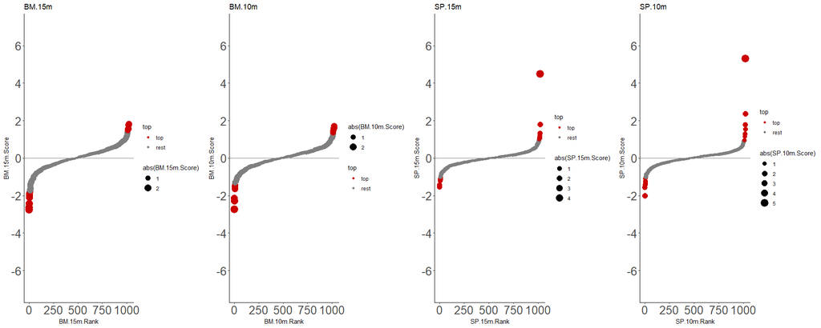

```r
inVivo
dev.off()
```

```r
in_Vitro <- ggarrange(ET.1.2.plot,ET.1.10.plot, ncol=2, nrow=1)
in_Vitro

pdf('inVitro_noLab.pdf',width=10, height=8)
```

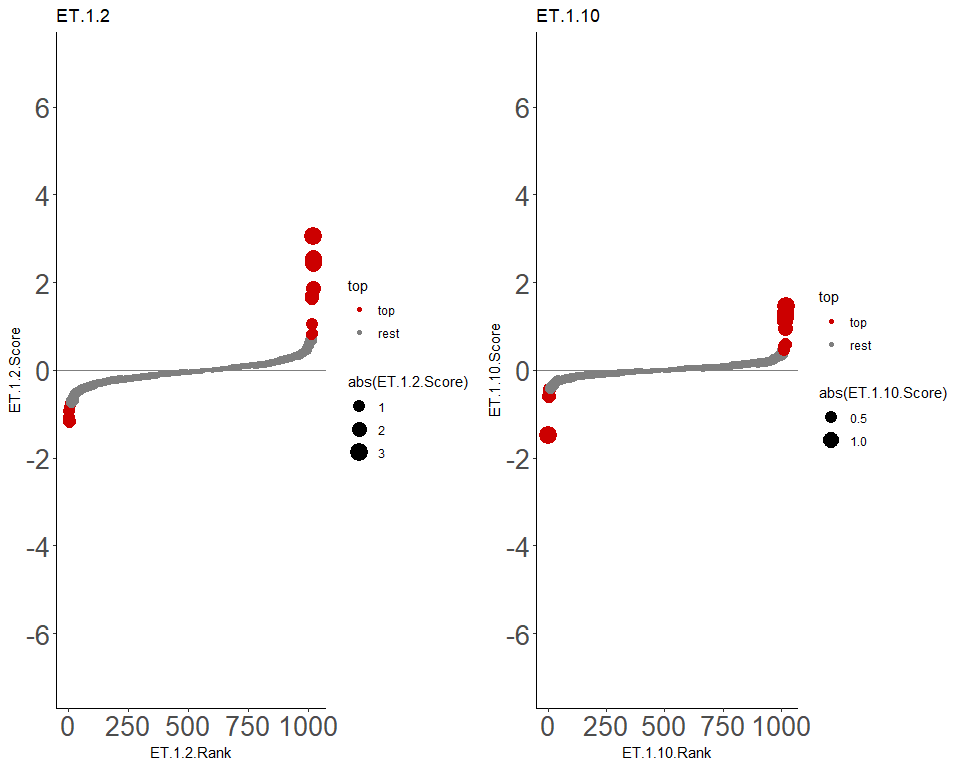

```r
print(ggarrange(ET.1.2.plot,ET.1.10.plot, ncol=2, nrow=1))
dev.off()
```

## second version

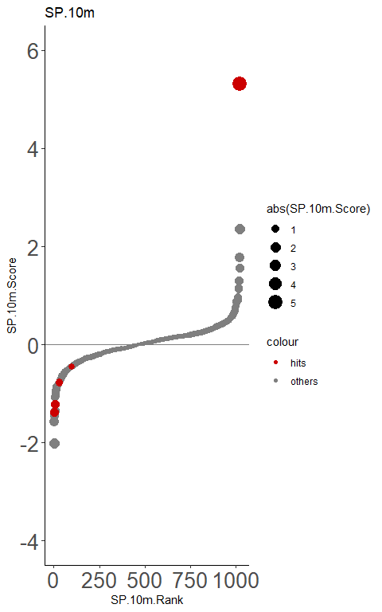

```r
sorted_df <- SP.10m %>% dplyr::arrange(SP.10m.Rank)
sorted_df <- sorted_df %>% mutate(top = if_else(sorted_df$SP.10m.Rank <= 10 | sorted_df$SP.10m.Rank >= (nrow(sorted_df)-9),"top","rest"))
sorted_df$color <- "others"
sorted_df$color[match(c("Jak1","Jak2","Stat1","Ifngr1","H2-T23","Cd19"),sorted_df$id)] <- "hits"
df_to_highlight <- sorted_df[match(c("Jak1","Jak2","Stat1","Ifngr1","H2-T23","Cd19"),sorted_df$id),]

SP.10m.plot <- ggplot(sorted_df, aes(x=SP.10m.Rank, y=SP.10m.Score)) + geom_point(aes(size=abs(SP.10m.Score), color = "grey50")) +
  geom_point(data=df_to_highlight, aes(size=abs(SP.10m.Score), color=color)) +
  scale_color_manual(values = c("hits" = "#CC0000", "others" = "grey50")) +
  theme_bw() +
#  geom_text_repel(data=df_to_highlight, aes(label = id), min.segment.length = 0) +
  theme(panel.border = element_blank(), panel.grid.major = element_blank(), panel.grid.minor = element_blank(), axis.line = element_line(color = "black")) +
  theme(axis.text=element_text(size=20)) +
  ggtitle("SP.10m") +
  scale_y_continuous(breaks=seq(-4,6,2), limits=c(-4,6)) + geom_hline(yintercept=0, color="grey50")
SP.10m.plot
```

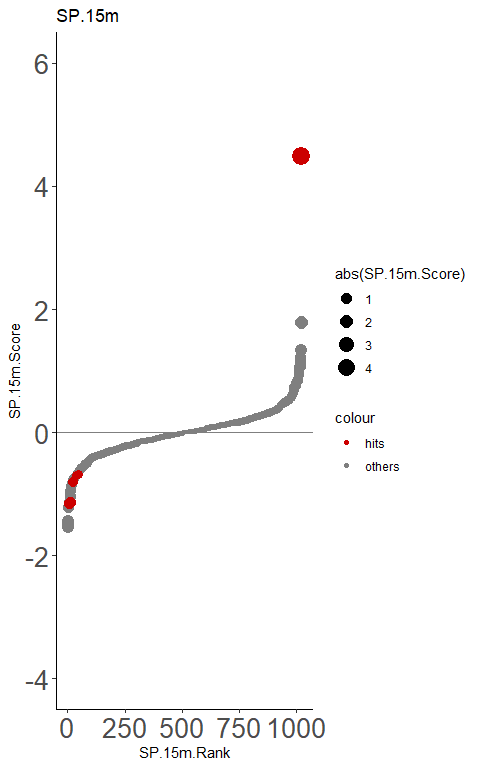

```r
########
sorted_df <- SP.15m %>% dplyr::arrange(SP.15m.Rank)
sorted_df <- sorted_df %>% mutate(top = if_else(sorted_df$SP.15m.Rank <= 10 | sorted_df$SP.15m.Rank >= (nrow(sorted_df)-9),"top","rest"))
sorted_df$color <- "others"
sorted_df$color[match(c("Jak1","Jak2","Stat1","Ifngr1","H2-T23","Cd19"),sorted_df$id)] <- "hits"
df_to_highlight <- sorted_df[match(c("Jak1","Jak2","Stat1","Ifngr1","H2-T23","Cd19"),sorted_df$id),]

SP.15m.plot <- ggplot(sorted_df, aes(x=SP.15m.Rank, y=SP.15m.Score)) + geom_point(aes(size=abs(SP.15m.Score), color = "grey50")) +
  geom_point(data=df_to_highlight, aes(size=abs(SP.15m.Score), color=color)) +
  scale_color_manual(values = c("hits" = "#CC0000", "others" = "grey50")) +
  theme_bw() +
#  geom_text_repel(data=df_to_highlight, aes(label = id), min.segment.length = 0) +
  theme(panel.border = element_blank(), panel.grid.major = element_blank(), panel.grid.minor = element_blank(), axis.line = element_line(color = "black")) +
  theme(axis.text=element_text(size=20)) +
  ggtitle("SP.15m") +
  scale_y_continuous(breaks=seq(-4,6,2), limits=c(-4,6)) + geom_hline(yintercept=0, color="grey50")
SP.15m.plot
```

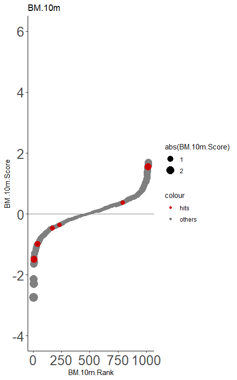

```r
########
sorted_df <- BM.10m %>% dplyr::arrange(BM.10m.Rank)
sorted_df <- sorted_df %>% mutate(top = if_else(sorted_df$BM.10m.Rank <= 10 | sorted_df$BM.10m.Rank >= (nrow(sorted_df)-9),"top","rest"))
sorted_df$color <- "others"
sorted_df$color[match(c("Jak1","Jak2","Stat1","Ifngr1","H2-T23","Cd19"),sorted_df$id)] <- "hits"
df_to_highlight <- sorted_df[match(c("Jak1","Jak2","Stat1","Ifngr1","H2-T23","Cd19"),sorted_df$id),]

BM.10m.plot <- ggplot(sorted_df, aes(x=BM.10m.Rank, y=BM.10m.Score)) + geom_point(aes(size=abs(BM.10m.Score), color = "grey50")) +
  geom_point(data=df_to_highlight, aes(size=abs(BM.10m.Score), color=color)) +
  scale_color_manual(values = c("hits" = "#CC0000", "others" = "grey50")) +
  theme_bw() +
#  geom_text_repel(data=df_to_highlight, aes(label = id), min.segment.length = 0) +
  theme(panel.border = element_blank(), panel.grid.major = element_blank(), panel.grid.minor = element_blank(), axis.line = element_line(color = "black")) +
  theme(axis.text=element_text(size=20)) +
  ggtitle("BM.10m") +
  scale_y_continuous(breaks=seq(-4,6,2), limits=c(-4,6)) + geom_hline(yintercept=0, color="grey50")
BM.10m.plot
```

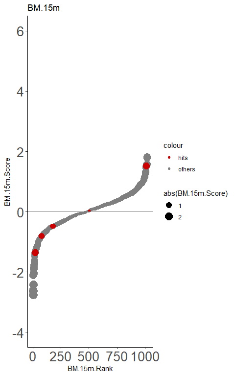

```r
########
sorted_df <- BM.15m %>% dplyr::arrange(BM.15m.Rank)
sorted_df <- sorted_df %>% mutate(top = if_else(sorted_df$BM.15m.Rank <= 10 | sorted_df$BM.15m.Rank >= (nrow(sorted_df)-9),"top","rest"))
sorted_df$color <- "others"
sorted_df$color[match(c("Jak1","Jak2","Stat1","Ifngr1","H2-T23","Cd19"),sorted_df$id)] <- "hits"
df_to_highlight <- sorted_df[match(c("Jak1","Jak2","Stat1","Ifngr1","H2-T23","Cd19"),sorted_df$id),]

BM.15m.plot <- ggplot(sorted_df, aes(x=BM.15m.Rank, y=BM.15m.Score)) + geom_point(aes(size=abs(BM.15m.Score), color = "grey50")) +
  geom_point(data=df_to_highlight, aes(size=abs(BM.15m.Score), color=color)) +
  scale_color_manual(values = c("hits" = "#CC0000", "others" = "grey50")) +
  theme_bw() +
#  geom_text_repel(data=df_to_highlight, aes(label = id), min.segment.length = 0) +
  theme(panel.border = element_blank(), panel.grid.major = element_blank(), panel.grid.minor = element_blank(), axis.line = element_line(color = "black")) +
  theme(axis.text=element_text(size=20)) +
  ggtitle("BM.15m") +
  scale_y_continuous(breaks=seq(-4,6,2), limits=c(-4,6)) + geom_hline(yintercept=0, color="grey50")
BM.15m.plot
```

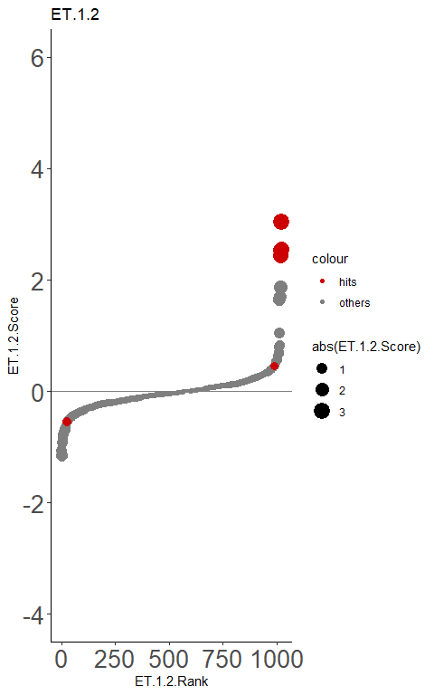

```r
########
########
sorted_df <-ET.1.2 %>% dplyr::arrange(ET.1.2.Rank)
sorted_df <- sorted_df %>% mutate(top = if_else(sorted_df$ET.1.2.Rank <= 10 | sorted_df$ET.1.2.Rank >= (nrow(sorted_df)-9),"top","rest"))
sorted_df$color <- "others"
sorted_df$color[match(c("Jak1","Jak2","Stat1","Ifngr1","H2-T23","Cd19"),sorted_df$id)] <- "hits"
df_to_highlight <- sorted_df[match(c("Jak1","Jak2","Stat1","Ifngr1","H2-T23","Cd19"),sorted_df$id),]

ET.1.2.plot <- ggplot(sorted_df, aes(x=ET.1.2.Rank, y=ET.1.2.Score)) + geom_point(aes(size=abs(ET.1.2.Score), color = "grey50")) +
  geom_point(data=df_to_highlight, aes(size=abs(ET.1.2.Score), color=color)) +
  scale_color_manual(values = c("hits" = "#CC0000", "others" = "grey50")) +
  theme_bw() +
#  geom_text_repel(data=df_to_highlight, aes(label = id), min.segment.length = 0) +
  theme(panel.border = element_blank(), panel.grid.major = element_blank(), panel.grid.minor = element_blank(), axis.line = element_line(color = "black")) +
  theme(axis.text=element_text(size=20)) +
  ggtitle("ET.1.2") +
  scale_y_continuous(breaks=seq(-4,6,2), limits=c(-4,6)) + geom_hline(yintercept=0, color="grey50")
ET.1.2.plot
```

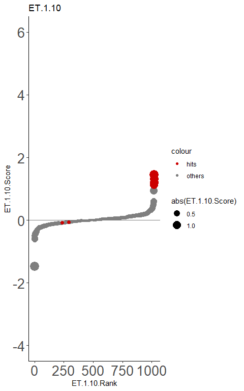

```r
########
sorted_df <-ET.1.10 %>% dplyr::arrange(ET.1.10.Rank)
sorted_df <- sorted_df %>% mutate(top = if_else(sorted_df$ET.1.10.Rank <= 10 | sorted_df$ET.1.10.Rank >= (nrow(sorted_df)-9),"top","rest"))
sorted_df$color <- "others"
sorted_df$color[match(c("Jak1","Jak2","Stat1","Ifngr1","H2-T23","Cd19"),sorted_df$id)] <- "hits"
df_to_highlight <- sorted_df[match(c("Jak1","Jak2","Stat1","Ifngr1","H2-T23","Cd19"),sorted_df$id),]

ET.1.10.plot <- ggplot(sorted_df, aes(x=ET.1.10.Rank, y=ET.1.10.Score)) + geom_point(aes(size=abs(ET.1.10.Score), color = "grey50")) +
  geom_point(data=df_to_highlight, aes(size=abs(ET.1.10.Score), color=color)) +
  scale_color_manual(values = c("hits" = "#CC0000", "others" = "grey50")) +
  theme_bw() +
#  geom_text_repel(data=df_to_highlight, aes(label = id), min.segment.length = 0) +
  theme(panel.border = element_blank(), panel.grid.major = element_blank(), panel.grid.minor = element_blank(), axis.line = element_line(color = "black")) +
  theme(axis.text=element_text(size=20)) +
  ggtitle("ET.1.10") +
  scale_y_continuous(breaks=seq(-4,6,2), limits=c(-4,6)) + geom_hline(yintercept=0, color="grey50")
ET.1.10.plot
```

```r
inVivo <- ggarrange(BM.15m.plot,BM.10m.plot,SP.15m.plot,SP.10m.plot, ncol=4, nrow=1)
inVivo

pdf('inVivo_noLab_v3.pdf',width=20, height=8)
```

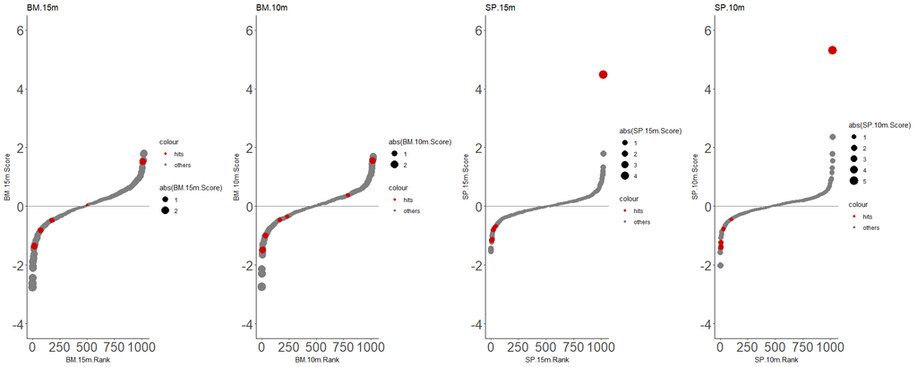

```r
inVivo
dev.off()
```

```r
in_Vitro <- ggarrange(ET.1.2.plot,ET.1.10.plot, ncol=2, nrow=1)
in_Vitro

pdf('inVitro_noLab_v3.pdf',width=10, height=8)
```

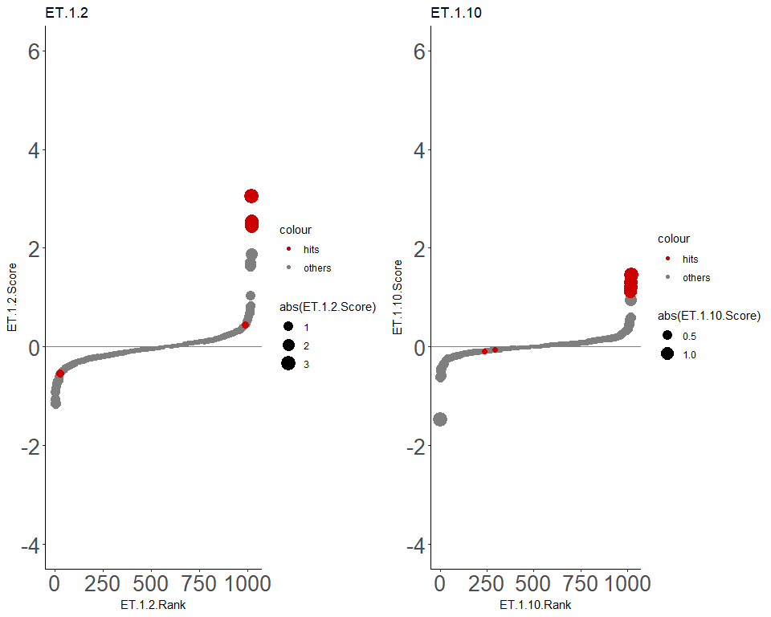

```r
print(ggarrange(ET.1.2.plot,ET.1.10.plot, ncol=2, nrow=1))
dev.off()
```

# Venn Diagrams - Prepare gene lists

```r
FDR.threshold <- 0.1
Score.threshold <- 1

SP_cd19.10m_v_egfr.15m.enrich <- SP_cd19.10m_v_egfr.15m.gdata %>% filter(Score >= Score.threshold & FDR <= FDR.threshold) %>% dplyr::select(c("id"))
SP_cd19.15m_v_egfr.15m.enrich <- SP_cd19.15m_v_egfr.15m.gdata %>% filter(Score >= Score.threshold & FDR <= FDR.threshold) %>% dplyr::select(c("id"))
BM_cd19.10m_v_egfr.15m.enrich <- BM_cd19.10m_v_egfr.15m.gdata %>% filter(Score >= Score.threshold & FDR <= FDR.threshold) %>% dplyr::select(c("id"))
BM_cd19.15m_v_egfr.15m.enrich <- BM_cd19.15m_v_egfr.15m.gdata %>% filter(Score >= Score.threshold & FDR <= FDR.threshold) %>% dplyr::select(c("id"))

cd19_1to2_v_egfr_1to2.enrich <- cd19_1to2_v_egfr_1to2.gdata %>% filter(Score >= Score.threshold & FDR <= FDR.threshold) %>% dplyr::select(c("id"))
cd19_1to10_v_egfr_1to10.enrich <- cd19_1to10_v_egfr_1to10.gdata %>% filter(Score >= Score.threshold & FDR <= FDR.threshold) %>% dplyr::select(c("id"))

SP_cd19.10m_v_egfr.15m.deplete <- SP_cd19.10m_v_egfr.15m.gdata %>% filter(Score <= -Score.threshold & FDR <= FDR.threshold) %>% dplyr::select(c("id"))
SP_cd19.15m_v_egfr.15m.deplete <- SP_cd19.15m_v_egfr.15m.gdata %>% filter(Score <= -Score.threshold & FDR <= FDR.threshold) %>% dplyr::select(c("id"))
BM_cd19.10m_v_egfr.15m.deplete <- BM_cd19.10m_v_egfr.15m.gdata %>% filter(Score <= -Score.threshold & FDR <= FDR.threshold) %>% dplyr::select(c("id"))
BM_cd19.15m_v_egfr.15m.deplete <- BM_cd19.15m_v_egfr.15m.gdata %>% filter(Score <= -Score.threshold & FDR <= FDR.threshold) %>% dplyr::select(c("id"))

cd19_1to2_v_egfr_1to2.deplete <- cd19_1to2_v_egfr_1to2.gdata %>% filter(Score <= -Score.threshold & FDR <= FDR.threshold) %>% dplyr::select(c("id"))
cd19_1to10_v_egfr_1to10.deplete <- cd19_1to10_v_egfr_1to10.gdata %>% filter(Score <= -Score.threshold & FDR <= FDR.threshold) %>% dplyr::select(c("id"))
```

```r
vivo.enrich <- rbind(SP_cd19.10m_v_egfr.15m.enrich,SP_cd19.15m_v_egfr.15m.enrich,BM_cd19.10m_v_egfr.15m.enrich,BM_cd19.15m_v_egfr.15m.enrich)
vivo.deplete <- rbind(SP_cd19.10m_v_egfr.15m.deplete,SP_cd19.15m_v_egfr.15m.deplete,BM_cd19.10m_v_egfr.15m.deplete,BM_cd19.15m_v_egfr.15m.deplete)

vitro.enrich <- rbind(cd19_1to2_v_egfr_1to2.enrich,cd19_1to10_v_egfr_1to10.enrich)
vitro.deplete <- rbind(cd19_1to2_v_egfr_1to2.deplete,cd19_1to10_v_egfr_1to10.deplete)
```

```r
vivo.enrich.unique <- unique(vivo.enrich$id)
vivo.deplete.unique <- unique(vivo.deplete$id)

vitro.enrich.unique <- unique(vitro.enrich$id)
vitro.deplete.unique <- unique(vitro.deplete$id)
```

## Generate venn diagrams from gene lists

[figure not shown]

```r
deplete.overlap <- calculate.overlap(
x = list(
"Vitro" = vitro.deplete.unique,
"Vivo" = vivo.deplete.unique
)
)

deplete.venn.plot <- draw.pairwise.venn(length(deplete.overlap$a1), length(deplete.overlap$a2),length(deplete.overlap$a3),
                                category = c("vitro.dep", "vivo.dep"),
                                fill = c("grey50", "grey50"),
                                rotation.degree = 180,
                                lty = "blank"
)
grid.draw(deplete.venn.plot)
grid.newpage()
```

```r
pdf(file="deplete_v2.pdf",width=6, height=6)
grid.draw(deplete.venn.plot)
```

```r
dev.off()
```

```r
####################
enrich.overlap <- calculate.overlap(
x = list(
"Vitro" = vitro.enrich.unique,
"Vivo" = vivo.enrich.unique
)
)

enrich.venn.plot <- draw.pairwise.venn(length(enrich.overlap$a2), length(enrich.overlap$a1), length(enrich.overlap$a3),
                                category = c("vitro.en", "vivo.en"),
                                fill = c("grey50", "grey50"),
                                rotation.degree = 180,
                                lty = "blank"
)
```

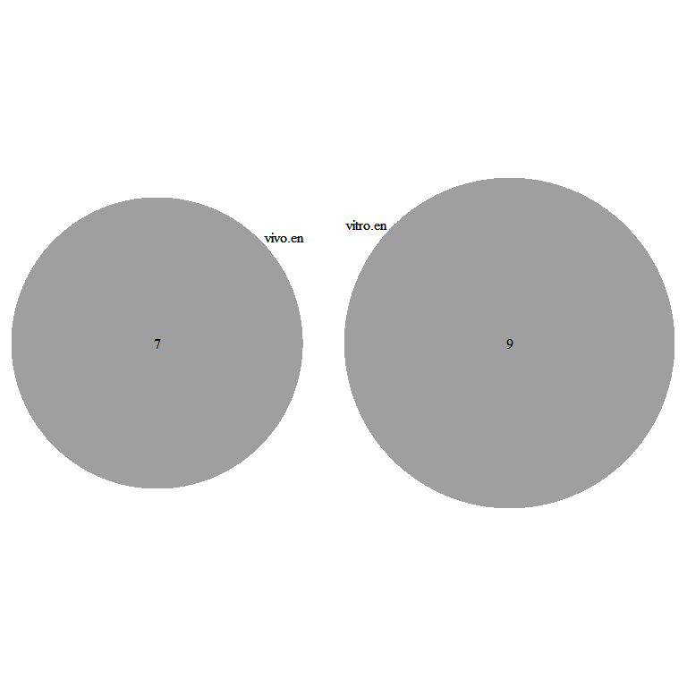

```r
grid.draw(enrich.venn.plot)
```

```r
grid.newpage()

pdf(file="enrich_v2.pdf",width=6, height=6)
```

```r
grid.draw(enrich.venn.plot)
dev.off()
```

## Checking Lists

```r
for (i in ls(pattern="m.deplete")){
  print(i)
  print((get(i)))
}
```

```
[1] "BM_cd19.10m_v_egfr.15m.deplete"
```

| id |
| --- |
| Pak2 |
| Fitm2 |
| Ptpn2 |
| Hacd3 |

```
[1] "BM_cd19.15m_v_egfr.15m.deplete"
```

| id |
| --- |
| Pak2 |
| Fitm2 |
| Ptpn2 |

```
[1] "SP_cd19.10m_v_egfr.15m.deplete"
```

| id |
| --- |
| Sipa1 |
| Pak2 |
| Ubr4 |
| Fitm2 |
| Irf1 |
| Ptpn2 |
| H2-T23 |
| Ifngr1 |
| Socs1 |

```
[1] "SP_cd19.15m_v_egfr.15m.deplete"
```

| id |
| --- |
| Pak2 |
| Capzb |
| Fitm2 |
| Tlnrd1 |
| Ptpn2 |
| Ifngr1 |
| H2-T23 |

# Viewing individual guides

## MPM_21_v_RPMI_21

```r
sgRankView(MPM_21_v_RPMI_21.sdata, top = 3, bottom = 3)

plotList <- MPM_21_v_RPMI_21.gdata %>% filter(abs(Score) > 1.2) %>% dplyr::select(id)
sgRankView(MPM_21_v_RPMI_21.sdata, top = 0, bottom = 0, gene=plotList$id)
```

## MPM_5_v_RPMI_5

```r
sgRankView(MPM_5_v_RPMI_5.sdata, top = 3, bottom = 3)

plotList <- MPM_5_v_RPMI_5.gdata %>% filter(abs(Score) > 1.2) %>% dplyr::select(id)
sgRankView(MPM_5_v_RPMI_5.sdata, top = 0, bottom = 0, gene=plotList$id)
```

## RPMI_5_v_RPMI_21

```r
sgRankView(RPMI_5_v_RPMI_21.sdata, top = 3, bottom = 3)

plotList <- RPMI_5_v_RPMI_21.gdata %>% filter(abs(Score) > 1.2) %>% dplyr::select(id)
sgRankView(RPMI_5_v_RPMI_21.sdata, top = 0, bottom = 0, gene=plotList$id)
```

## MPM_5_v_MPM_21

```r
sgRankView(MPM_5_v_MPM_21.sdata, top = 3, bottom = 3)

plotList <- MPM_5_v_MPM_21.gdata %>% filter(abs(Score) > 1.2) %>% dplyr::select(id)
sgRankView(MPM_5_v_MPM_21.sdata, top = 0, bottom = 0, gene=plotList$id)
```

```r
goiToPlot <- as.data.frame(c("Ifngr1","Jak2","Stat1","H2-T23","Cd19"))
colnames(goiToPlot) <- 'id'
```

## SP_cd19.10m_v_egfr.15m

```r
#sgRankView(SP_cd19.10m_v_egfr.15m.sdata, top = 3, bottom = 3)

#plotList <- SP_cd19.10m_v_egfr.15m.gdata %>% filter(abs(Score) > 1.2) %>% select(id)
#plotList <- SP_cd19.10m_v_egfr.15m.gdata %>% filter(id %in% c("Ifngr1", "Jak2", "Stat1", "Qa-1", "Cd19")) %>% select(id)

gv1 <- sgRankView(SP_cd19.10m_v_egfr.15m.sdata, top = 0, bottom = 0, gene=goiToPlot$id) + xlim(-7, 7) +
  ggtitle("SP_cd19.10m_v_egfr.15m") + theme(plot.title = element_text(size = 12, face = "bold"))
gv1
```

## SP_cd19.15m_v_egfr.15m

```r
#sgRankView(SP_cd19.15m_v_egfr.15m.sdata, top = 3, bottom = 3)

#plotList <- SP_cd19.15m_v_egfr.15m.gdata %>% filter(abs(Score) > 1.2) %>% select(id)
#plotList <- SP_cd19.15m_v_egfr.15m.gdata %>% filter(id %in% c("Ifngr1", "Jak2", "Stat1", "Qa-1", "Cd19")) %>% select(id)

gv2 <- sgRankView(SP_cd19.15m_v_egfr.15m.sdata, top = 0, bottom = 0, gene=goiToPlot$id) + xlim(-7, 7) +
  ggtitle("SP_cd19.15m_v_egfr.15m") + theme(plot.title = element_text(size = 12, face = "bold"))
gv2
```

## BM_cd19.10m_v_egfr.15m

```r
#sgRankView(BM_cd19.10m_v_egfr.15m.sdata, top = 3, bottom = 3)

#plotList <- BM_cd19.10m_v_egfr.15m.gdata %>% filter(abs(Score) > 1.2) %>% select(id)
#plotList <- BM_cd19.10m_v_egfr.15m.gdata %>% arrange(id) %>% filter(id %in% c("Ifngr1", "Jak2", "Stat1", "Qa-1", "Cd19")) %>% select(id)
gv3 <- sgRankView(BM_cd19.10m_v_egfr.15m.sdata, top = 0, bottom = 0, gene=goiToPlot$id) + xlim(-7, 7) +
  ggtitle("BM_cd19.10m_v_egfr.15m") + theme(plot.title = element_text(size = 12, face = "bold"))

gv3
```

## BM_cd19.15m_v_egfr.15m

```r
#sgRankView(BM_cd19.15m_v_egfr.15m.sdata, top = 3, bottom = 3)

#plotList <- BM_cd19.15m_v_egfr.15m.gdata %>% filter(abs(Score) > 1.2) %>% select(id)
#plotList <- BM_cd19.15m_v_egfr.15m.gdata %>% filter(id %in% c("Ifngr1", "Jak2", "Stat1", "Qa-1", "Cd19")) %>% select(id)

gv4 <- sgRankView(BM_cd19.15m_v_egfr.15m.sdata, top = 0, bottom = 0, gene=goiToPlot$id) + xlim(-7, 7) +
  ggtitle("BM_cd19.15m_v_egfr.15m") + theme(plot.title = element_text(size = 12, face = "bold"))
gv4
```

## cd19_1to2_v_egfr_1to2

```r
#sgRankView(cd19_1to2_v_egfr_1to2.sdata, top = 3, bottom = 3)

#plotList <- cd19_1to2_v_egfr_1to2.gdata %>% filter(abs(Score) > 1.2) %>% select(id)
#plotList <- cd19_1to2_v_egfr_1to2.gdata %>% filter(id %in% c("Ifngr1", "Jak2", "Stat1", "Qa-1", "Cd19")) %>% select(id)

gv5 <- sgRankView(cd19_1to2_v_egfr_1to2.sdata, top = 0, bottom = 0, gene=goiToPlot$id) + xlim(-7, 7) +
  ggtitle("cd19_1to2_v_egfr_1to2") + theme(plot.title = element_text(size = 12, face = "bold"))
gv5
```

## cd19_1to10_v_egfr_1to10

```r
#sgRankView(cd19_1to10_v_egfr_1to10.sdata, top = 3, bottom = 3)

#plotList <- cd19_1to10_v_egfr_1to10.gdata %>% filter(abs(Score) > 1.2) %>% select(id)
#plotList <- cd19_1to10_v_egfr_1to10.gdata %>% filter(id %in% c("Ifngr1", "Jak2", "Stat1", "Qa-1", "Cd19")) %>% select(id)

gv6 <- sgRankView(cd19_1to10_v_egfr_1to10.sdata, top = 0, bottom = 0, gene=goiToPlot$id) + xlim(-7, 7) +
  ggtitle("cd19_1to10_v_egfr_1to10") + theme(plot.title = element_text(size = 12, face = "bold"))
gv6
```

# in vivo guides

```r
ggarrange(gv1,gv2,gv3,gv4, ncol=4, nrow=1)
```

# in vitro guides

```r
ggarrange(gv5,gv6, ncol=2, nrow=1)
```

# Comparison of mageck and YL method FCs

```r
SP_cd19.10m_v_egfr.15m.gdata.toMerge <- SP_cd19.10m_v_egfr.15m.gdata %>% dplyr::select(id,Score)
colnames(SP_cd19.10m_v_egfr.15m.gdata.toMerge) <- c("Gene","SP_cd19.10m_v_egfr.15m.mageck.lfc")

SP_cd19.15m_v_egfr.15m.gdata.toMerge <- SP_cd19.15m_v_egfr.15m.gdata %>% dplyr::select(id,Score)
colnames(SP_cd19.15m_v_egfr.15m.gdata.toMerge) <- c("Gene","SP_cd19.15m_v_egfr.15m.mageck.lfc")

BM_cd19.10m_v_egfr.15m.gdata.toMerge <- BM_cd19.10m_v_egfr.15m.gdata %>% dplyr::select(id,Score)
colnames(BM_cd19.10m_v_egfr.15m.gdata.toMerge) <- c("Gene","BM_cd19.10m_v_egfr.15m.mageck.lfc")

BM_cd19.15m_v_egfr.15m.gdata.toMerge <- BM_cd19.15m_v_egfr.15m.gdata %>% dplyr::select(id,Score)
colnames(BM_cd19.15m_v_egfr.15m.gdata.toMerge) <- c("Gene","BM_cd19.15m_v_egfr.15m.mageck.lfc")

cd19_1to2_v_egfr_1to2.gdata.toMerge <- cd19_1to2_v_egfr_1to2.gdata %>% dplyr::select(id,Score)
colnames(cd19_1to2_v_egfr_1to2.gdata.toMerge) <- c("Gene","cd19_1to2_v_egfr_1to2.mageck.lfc")

cd19_1to10_v_egfr_1to10.gdata.toMerge <- cd19_1to10_v_egfr_1to10.gdata %>% dplyr::select(id,Score)
colnames(cd19_1to10_v_egfr_1to10.gdata.toMerge) <- c("Gene","cd19_1to10_v_egfr_1to10.mageck.lfc")

FCcombined <- merge(x=GeneMeans,y=SP_cd19.10m_v_egfr.15m.gdata.toMerge, by.x=c("Gene"),by.y=c("Gene"), all=TRUE)
FCcombined <- merge(x=FCcombined,y=SP_cd19.15m_v_egfr.15m.gdata.toMerge, by.x=c("Gene"),by.y=c("Gene"), all=TRUE)
FCcombined <- merge(x=FCcombined,y=BM_cd19.10m_v_egfr.15m.gdata.toMerge, by.x=c("Gene"),by.y=c("Gene"), all=TRUE)
FCcombined <- merge(x=FCcombined,y=BM_cd19.15m_v_egfr.15m.gdata.toMerge, by.x=c("Gene"),by.y=c("Gene"), all=TRUE)
FCcombined <- merge(x=FCcombined,y=cd19_1to2_v_egfr_1to2.gdata.toMerge, by.x=c("Gene"),by.y=c("Gene"), all=TRUE)
FCcombined <- merge(x=FCcombined,y=cd19_1to10_v_egfr_1to10.gdata.toMerge, by.x=c("Gene"),by.y=c("Gene"), all=TRUE)
```

## Add column to highlight genes

```r
toHighlight <- c('Jak2','Stat1','Ifngr1','H2-T23','Cd19')

#FCcombined <- tibble::rownames_to_column(FCcombined, "Gene")
FCcombined <- FCcombined %>% mutate(Highlight = ifelse(Gene %in% toHighlight,"Yes","No"))
```

## Plotting fold change comparisons

```r
hits <- FCcombined %>% filter(Highlight=="Yes")
geom.text.size <- 5
a <- FCcombined %>% ggplot(aes(x=SP_cd19.10m_v_egfr.15m.fc.Gene, y=SP_cd19.10m_v_egfr.15m.mageck.lfc))+
  geom_point()+
  geom_text_repel(data=hits,
                  aes(x=SP_cd19.10m_v_egfr.15m.fc.Gene,
                      y=SP_cd19.10m_v_egfr.15m.mageck.lfc,
                      label=Gene),
                  color = "red", size=geom.text.size)+
  geom_abline() + xlim(-5.5,5.5) + ylim(-5.5,5.5) + ggtitle("SP_cd19.10m_v_egfr.15m") + theme(plot.title = element_text(size = 16, face = "bold"))

b <- FCcombined %>% ggplot(aes(x = SP_cd19.15m_v_egfr.15m.fc.Gene, y = SP_cd19.15m_v_egfr.15m.mageck.lfc))+
  geom_point()+
  geom_text_repel(data=hits,
                  aes(x=SP_cd19.15m_v_egfr.15m.fc.Gene,
                      y=SP_cd19.15m_v_egfr.15m.mageck.lfc,
                      label=Gene),
                  color = "red", size=geom.text.size)+
  geom_abline() + xlim(-5.5,5.5) + ylim(-5.5,5.5) + ggtitle("SP_cd19.15m_v_egfr.15m") + theme(plot.title = element_text(size = 16, face = "bold"))

c <- FCcombined %>% ggplot(aes(x = BM_cd19.10m_v_egfr.15m.fc.Gene, y = BM_cd19.10m_v_egfr.15m.mageck.lfc))+
  geom_point()+
  geom_text_repel(data=hits,
                  aes(x=BM_cd19.10m_v_egfr.15m.fc.Gene,
                      y=BM_cd19.10m_v_egfr.15m.mageck.lfc,
                      label=Gene),
                  color = "red", size=geom.text.size)+
  geom_abline() + xlim(-5.5,5.5) + ylim(-5.5,5.5) + ggtitle("BM_cd19.10m_v_egfr.15m") + theme(plot.title = element_text(size = 16, face = "bold"))

d <- FCcombined %>% ggplot(aes(x = BM_cd19.15m_v_egfr.15m.fc.Gene, y = BM_cd19.15m_v_egfr.15m.mageck.lfc))+
  geom_point()+
  geom_text_repel(data=hits,
                  aes(x=BM_cd19.15m_v_egfr.15m.fc.Gene,
                      y=BM_cd19.15m_v_egfr.15m.mageck.lfc,
                      label=Gene),
                  color = "red", size=geom.text.size)+
  geom_abline() + xlim(-5.5,5.5) + ylim(-5.5,5.5) + ggtitle("BM_cd19.15m_v_egfr.15m") + theme(plot.title = element_text(size = 16, face = "bold"))

e <- FCcombined %>% ggplot(aes(x = cd19_1to2_v_egfr_1to2.fc.Gene, y = cd19_1to2_v_egfr_1to2.mageck.lfc))+
  geom_point()+
  geom_text_repel(data=hits,
                  aes(x=cd19_1to2_v_egfr_1to2.fc.Gene,
                      y=cd19_1to2_v_egfr_1to2.mageck.lfc,
                      label=Gene),
                  color = "red", size=geom.text.size)+
  geom_abline() + xlim(-5.5,5.5) + ylim(-5.5,5.5) + ggtitle("cd19_1to2_v_egfr_1to2") + theme(plot.title = element_text(size = 16, face = "bold"))

f <- FCcombined %>% ggplot(aes(x = cd19_1to10_v_egfr_1to10.fc.Gene, y = cd19_1to10_v_egfr_1to10.mageck.lfc))+
  geom_point()+
  geom_text_repel(data=hits,
                  aes(x=cd19_1to10_v_egfr_1to10.fc.Gene,
                      y=cd19_1to10_v_egfr_1to10.mageck.lfc,
                      label=Gene),
                  color = "red", size=geom.text.size)+
  geom_abline() + xlim(-5.5,5.5) + ylim(-5.5,5.5) + ggtitle("cd19_1to10_v_egfr_1to10") + theme(plot.title = element_text(size = 16, face = "bold"))

ggarrange(a,b,c,d,e,f, ncol=6, nrow=1)
```

# Gene-wise work

## Editing sgRankView function to plot comparison name instead of gene

```r
sgRankView.cw <- function(df, gene = NULL,
                       top = 3, bottom = 3,
                       neg_ctrl = NULL,
                       binwidth = 0.3,
                       interval = 0.1,
                       bg.col = "gray90",
                       filename = NULL,
                       width = 5, height = 3.5,
                       ...){
  if(!all(c("sgrna", "Gene", "LFC") %in% colnames(df)))
    stop("Make sure your data contains columns of 'sgrna', 'Gene', and 'LFC' ...")
  df = as.data.frame(df, stringsAsFactors = FALSE)
  df = df[order(df$LFC), ]
  df$Gene = as.character(df$Gene)
  tmp = stats::aggregate(df$LFC, by = list(df$Gene), median)
  colnames(tmp) = c("Gene", "mid")
  tmp = tmp[order(tmp$mid), ]
  if(top>0){
    idx = max((nrow(tmp)-top+1), 1)
    gene = c(gene, tmp$Gene[idx:nrow(tmp)])
  }
  if(bottom>0){
    gene = c(gene, tmp$Gene[1:min(bottom, nrow(tmp))])
  }
  gene = unique(gene)

  subdf = df[df$Gene%in%gene, ]
  if(nrow(subdf)<2) return(ggplot())
  subdf$Gene = factor(subdf$Gene, levels = gene)
  subdf = subdf[order(subdf$Gene), ]
  subdf$index = rep(1:length(gene), as.numeric(table(subdf$Gene)[gene]))
  subdf$yend <- (binwidth+interval)*subdf$index-interval
  subdf$y <- (binwidth+interval)*(subdf$index-1)
  color <- c(rep("pos",dim(subdf)[1]))
  color[which(subdf[,3]<0)] <- "neg"
  subdf$color <- color
  subdf = subdf[, c("sgrna", "Gene", "LFC", "y", "yend", "color", "index")]

  #set the scale of x-axis
  a <- -Inf
  b <- Inf

  #bgcor
  if(is.na(bg.col)){bg.col<-"white"}
  bindex <- as.vector(sapply(seq(1,max(subdf$index),1),function(x){rep(x,4)}))
  bgcol <- data.frame(as.vector(bindex))
  bgcol$color <- c(rep("bg",length(bindex)))
  colnames(bgcol)<- c("id","value")
  bgcol$x <-  rep(c(a,b,b,a),max(subdf$index))
  bgcol$y <-as.vector(sapply(seq(1,max(subdf$index),1), function(x){
    c((interval + binwidth)*(x-1), (interval + binwidth)*(x-1),
      (interval + binwidth)*x-interval,(interval + binwidth)*x-interval)
    }))

  #background
  if(!is.null(neg_ctrl)){
    neggene = rep(df[df$Gene %in% neg_ctrl, "Gene"], max(subdf$index))
    negsgrna = rep(df[df$Gene %in% neg_ctrl, "sgrna"], max(subdf$index))
    background <- data.frame(sgrna = as.vector(negsgrna), Gene = as.vector(neggene))
    background$LFC <- rep(df[df$Gene %in% neg_ctrl,3], max(subdf$index))
    seq <- as.vector(sapply(seq(1,max(subdf$index),1), function(x){
      rep(x,length(df[df$Gene %in% neg_ctrl,2]))}))
    background$y <- (binwidth+interval)*(seq-1)
    background$yend <-(binwidth+interval)*seq-interval
    background$color <-rep("tbg",length(neggene))
    background$index = 0
  }

  #depict
  cols <- c("pos"="#e41a1c","neg"="#377eb8", "tbg" = 608, "black"="black")
  p = ggplot()
  p = p + geom_polygon(aes_string("x", "y", fill="value", group="id"), color="gray20", data=bgcol)
  if(!is.null(neg_ctrl))
    p = p + geom_segment(aes_string("LFC", "y", xend = "LFC", yend = "yend", color = "color"), data = background)
  p = p + geom_segment(aes_string("LFC", "y", xend = "LFC", yend = "yend", color = "color"), data = subdf)
  p = p + scale_color_manual(values = cols)
  p = p + scale_fill_manual(values = c("bg"= bg.col))
  # p = p + scale_x_continuous(expand = c(0, 0))
  p = p + scale_y_continuous(breaks = bgcol$y[seq(1, nrow(bgcol), 4)] + binwidth/2,
                             labels = i, expand = c(0, 0),position = "left")
  p = p + labs(x = "Log2(Fold change)", y = NULL)
  p = p + theme(text = element_text(colour="black",size = 14, family = "Helvetica"),
                plot.title = element_text(hjust = 0.5, size=18),
                axis.text = element_text(colour="gray10"))
  p = p + theme(axis.line = element_blank(),
                panel.grid.major = element_blank(), panel.grid.minor = element_blank(),
                panel.border = element_blank(), panel.background = element_blank())
  p = p + theme(legend.position = "none")

  if(!is.null(filename)){
    ggsave(plot=p, filename=filename, units = "in", width=width, height=height, ...)
  }
  return(p)
}
```

```r
goiToPlot <- as.data.frame(c("Ifngr1","Jak2","Stat1","H2-T23","Cd19"))
colnames(goiToPlot) <- 'id'
```

```r
BM_cd19.10m_v_egfr.15m.sdata$comparison <- "BM_cd19.10m_v_egfr.15m"
BM_cd19.15m_v_egfr.15m.sdata$comparison <- "BM_cd19.15m_v_egfr.15m"
SP_cd19.10m_v_egfr.15m.sdata$comparison <- "SP_cd19.10m_v_egfr.15m"
SP_cd19.15m_v_egfr.15m.sdata$comparison <- "SP_cd19.15m_v_egfr.15m"
cd19_1to10_v_egfr_1to10.sdata$comparison <- "cd19_1to10_v_egfr_1to10"
cd19_1to2_v_egfr_1to2.sdata$comparison <- "cd19_1to2_v_egfr_1to2"

MPM_21_v_RPMI_21.sdata$comparison <- "MPM_21_v_RPMI_21"
MPM_5_v_MPM_21.sdata$comparison <- "MPM_5_v_MPM_21"
MPM_5_v_RPMI_5.sdata$comparison <- "MPM_5_v_RPMI_5"
RPMI_5_v_RPMI_21.sdata$comparison <- "RPMI_5_v_RPMI_21"

AR.allGuides <- rbind(BM_cd19.10m_v_egfr.15m.sdata, BM_cd19.15m_v_egfr.15m.sdata,
                      SP_cd19.10m_v_egfr.15m.sdata,SP_cd19.15m_v_egfr.15m.sdata,
                      cd19_1to10_v_egfr_1to10.sdata, cd19_1to2_v_egfr_1to2.sdata)
```

```r
sample_group <- (c("BM_cd19.10m_v_egfr.15m", "BM_cd19.15m_v_egfr.15m",
                   "SP_cd19.10m_v_egfr.15m","SP_cd19.15m_v_egfr.15m",
                   "cd19_1to10_v_egfr_1to10","cd19_1to2_v_egfr_1to2"))

goiToPlot <- as.data.frame(c("Ifngr1","Jak2","Stat1","H2-T23","Cd19"))
colnames(goiToPlot) <- 'id'

for (i in sample_group){
  assign(paste0(i,".sgplot"),sgRankView.cw(AR.allGuides %>% filter(comparison == i), top = 0, bottom = 0,
                                        gene="Cd19",bg.col="white") +
           xlim(-7, 7) +
           theme(axis.title=element_blank(),legend.position = "none"))
}

Multiplot <- ggarrange(BM_cd19.10m_v_egfr.15m.sgplot,BM_cd19.15m_v_egfr.15m.sgplot,
                       SP_cd19.10m_v_egfr.15m.sgplot, SP_cd19.15m_v_egfr.15m.sgplot,
                       cd19_1to10_v_egfr_1to10.sgplot, cd19_1to2_v_egfr_1to2.sgplot, ncol=1)

sg.Cd19 <- annotate_figure(Multiplot, top = text_grob("Cd19", color = "black", face = "bold", size = 10))
##########
for (i in sample_group){
  assign(paste0(i,".sgplot"),sgRankView.cw(AR.allGuides %>% filter(comparison == i), top = 0, bottom = 0,
                                        gene="Ifngr1",bg.col="white") +
           xlim(-7, 7) +
           theme(axis.title=element_blank(),legend.position = "none"))
}

Multiplot <- ggarrange(BM_cd19.10m_v_egfr.15m.sgplot,BM_cd19.15m_v_egfr.15m.sgplot,
                       SP_cd19.10m_v_egfr.15m.sgplot, SP_cd19.15m_v_egfr.15m.sgplot,
                       cd19_1to10_v_egfr_1to10.sgplot, cd19_1to2_v_egfr_1to2.sgplot, ncol=1)

sg.Ifngr1 <- annotate_figure(Multiplot, top = text_grob("Ifngr1",
               color = "black", face = "bold", size = 10))
#########
for (i in sample_group){
  assign(paste0(i,".sgplot"),sgRankView.cw(AR.allGuides %>% filter(comparison == i), top = 0, bottom = 0,
                                        gene="Ifngr1",bg.col="white") +
           xlim(-7, 7) +
           theme(axis.title=element_blank(),legend.position = "none"))
}

Multiplot <- ggarrange(BM_cd19.10m_v_egfr.15m.sgplot,BM_cd19.15m_v_egfr.15m.sgplot,
                       SP_cd19.10m_v_egfr.15m.sgplot, SP_cd19.15m_v_egfr.15m.sgplot,
                       cd19_1to10_v_egfr_1to10.sgplot, cd19_1to2_v_egfr_1to2.sgplot, ncol=1)

sg.Ifngr1 <- annotate_figure(Multiplot, top = text_grob("Ifngr1",
               color = "black", face = "bold", size = 10))
#########
for (i in sample_group){
  assign(paste0(i,".sgplot"),sgRankView.cw(AR.allGuides %>% filter(comparison == i), top = 0, bottom = 0,
                                        gene="Jak2",bg.col="white") +
           xlim(-7, 7) +
           theme(axis.title=element_blank(),legend.position = "none"))
}

Multiplot <- ggarrange(BM_cd19.10m_v_egfr.15m.sgplot,BM_cd19.15m_v_egfr.15m.sgplot,
                       SP_cd19.10m_v_egfr.15m.sgplot, SP_cd19.15m_v_egfr.15m.sgplot,
                       cd19_1to10_v_egfr_1to10.sgplot, cd19_1to2_v_egfr_1to2.sgplot, ncol=1)

sg.Jak2 <- annotate_figure(Multiplot, top = text_grob("Jak2",
               color = "black", face = "bold", size = 10))
#########
for (i in sample_group){
  assign(paste0(i,".sgplot"),sgRankView.cw(AR.allGuides %>% filter(comparison == i), top = 0, bottom = 0,
                                        gene="Stat1",bg.col="white") +
           xlim(-7, 7) +
           theme(axis.title=element_blank(),legend.position = "none"))
}

Multiplot <- ggarrange(BM_cd19.10m_v_egfr.15m.sgplot,BM_cd19.15m_v_egfr.15m.sgplot,
                       SP_cd19.10m_v_egfr.15m.sgplot, SP_cd19.15m_v_egfr.15m.sgplot,
                       cd19_1to10_v_egfr_1to10.sgplot, cd19_1to2_v_egfr_1to2.sgplot, ncol=1)

sg.Stat1 <- annotate_figure(Multiplot, top = text_grob("Stat1",
               color = "black", face = "bold", size = 10))
#########
for (i in sample_group){
  assign(paste0(i,".sgplot"),sgRankView.cw(AR.allGuides %>% filter(comparison == i), top = 0, bottom = 0,
                                        gene="H2-T23",bg.col="white") +
           xlim(-7, 7) +
           theme(axis.title=element_blank(),legend.position = "none"))
}

Multiplot <- ggarrange(BM_cd19.10m_v_egfr.15m.sgplot,BM_cd19.15m_v_egfr.15m.sgplot,
                       SP_cd19.10m_v_egfr.15m.sgplot, SP_cd19.15m_v_egfr.15m.sgplot,
                       cd19_1to10_v_egfr_1to10.sgplot, cd19_1to2_v_egfr_1to2.sgplot, ncol=1)

sg.H2T23 <- annotate_figure(Multiplot, top = text_grob("H2-T23",
               color = "black", face = "bold", size = 10))
```

```r
ggarrange(sg.Cd19,sg.Ifngr1,sg.Jak2,sg.Stat1,sg.H2T23, ncol=5)
```

```r
sample_group <- (c("BM_cd19.10m_v_egfr.15m", "BM_cd19.15m_v_egfr.15m",
                   "SP_cd19.10m_v_egfr.15m","SP_cd19.15m_v_egfr.15m",
                   "cd19_1to10_v_egfr_1to10","cd19_1to2_v_egfr_1to2"))

goiToPlot <- as.data.frame(c("Ifngr1","Jak2","Stat1","H2-T23","Cd19"))
colnames(goiToPlot) <- 'id'

for (i in sample_group){
  assign(paste0(i,".sgplot"),sgRankView.cw(AR.allGuides %>% filter(comparison == i), top = 0, bottom = 0,
                                        gene="Cd19",bg.col="white") +
           xlim(-7, 7) +
           theme(axis.title=element_blank(),axis.text=element_blank(),legend.position = "none"))
}

Multiplot <- ggarrange(BM_cd19.10m_v_egfr.15m.sgplot,BM_cd19.15m_v_egfr.15m.sgplot,
                       SP_cd19.10m_v_egfr.15m.sgplot, SP_cd19.15m_v_egfr.15m.sgplot,
                       cd19_1to10_v_egfr_1to10.sgplot, cd19_1to2_v_egfr_1to2.sgplot, ncol=1)

sg.Cd19 <- annotate_figure(Multiplot, top = text_grob("Cd19", color = "black", face = "bold", size = 10))
##########
for (i in sample_group){
  assign(paste0(i,".sgplot"),sgRankView.cw(AR.allGuides %>% filter(comparison == i), top = 0, bottom = 0,
                                        gene="Ifngr1",bg.col="white") +
           xlim(-7, 7) +
           theme(axis.title=element_blank(),axis.text=element_blank(),legend.position = "none"))
}

Multiplot <- ggarrange(BM_cd19.10m_v_egfr.15m.sgplot,BM_cd19.15m_v_egfr.15m.sgplot,
                       SP_cd19.10m_v_egfr.15m.sgplot, SP_cd19.15m_v_egfr.15m.sgplot,
                       cd19_1to10_v_egfr_1to10.sgplot, cd19_1to2_v_egfr_1to2.sgplot, ncol=1)

sg.Ifngr1 <- annotate_figure(Multiplot, top = text_grob("Ifngr1",
               color = "black", face = "bold", size = 10))
#########
for (i in sample_group){
  assign(paste0(i,".sgplot"),sgRankView.cw(AR.allGuides %>% filter(comparison == i), top = 0, bottom = 0,
                                        gene="Ifngr1",bg.col="white") +
           xlim(-7, 7) +
           theme(axis.title=element_blank(),axis.text=element_blank(),legend.position = "none"))
}

Multiplot <- ggarrange(BM_cd19.10m_v_egfr.15m.sgplot,BM_cd19.15m_v_egfr.15m.sgplot,
                       SP_cd19.10m_v_egfr.15m.sgplot, SP_cd19.15m_v_egfr.15m.sgplot,
                       cd19_1to10_v_egfr_1to10.sgplot, cd19_1to2_v_egfr_1to2.sgplot, ncol=1)

sg.Ifngr1 <- annotate_figure(Multiplot, top = text_grob("Ifngr1",
               color = "black", face = "bold", size = 10))
#########
for (i in sample_group){
  assign(paste0(i,".sgplot"),sgRankView.cw(AR.allGuides %>% filter(comparison == i), top = 0, bottom = 0,
                                        gene="Jak2",bg.col="white") +
           xlim(-7, 7) +
           theme(axis.title=element_blank(),axis.text=element_blank(),legend.position = "none"))
}

Multiplot <- ggarrange(BM_cd19.10m_v_egfr.15m.sgplot,BM_cd19.15m_v_egfr.15m.sgplot,
                       SP_cd19.10m_v_egfr.15m.sgplot, SP_cd19.15m_v_egfr.15m.sgplot,
                       cd19_1to10_v_egfr_1to10.sgplot, cd19_1to2_v_egfr_1to2.sgplot, ncol=1)

sg.Jak2 <- annotate_figure(Multiplot, top = text_grob("Jak2",
               color = "black", face = "bold", size = 10))
#########
for (i in sample_group){
  assign(paste0(i,".sgplot"),sgRankView.cw(AR.allGuides %>% filter(comparison == i), top = 0, bottom = 0,
                                        gene="Stat1",bg.col="white") +
           xlim(-7, 7) +
           theme(axis.title=element_blank(),axis.text=element_blank(),legend.position = "none"))
}

Multiplot <- ggarrange(BM_cd19.10m_v_egfr.15m.sgplot,BM_cd19.15m_v_egfr.15m.sgplot,
                       SP_cd19.10m_v_egfr.15m.sgplot, SP_cd19.15m_v_egfr.15m.sgplot,
                       cd19_1to10_v_egfr_1to10.sgplot, cd19_1to2_v_egfr_1to2.sgplot, ncol=1)

sg.Stat1 <- annotate_figure(Multiplot, top = text_grob("Stat1",
               color = "black", face = "bold", size = 10))
#########
for (i in sample_group){
  assign(paste0(i,".sgplot"),sgRankView.cw(AR.allGuides %>% filter(comparison == i), top = 0, bottom = 0,
                                        gene="H2-T23",bg.col="white") +
           xlim(-7, 7) +
           theme(axis.title=element_blank(),axis.text=element_blank(),legend.position = "none"))
}

Multiplot <- ggarrange(BM_cd19.10m_v_egfr.15m.sgplot,BM_cd19.15m_v_egfr.15m.sgplot,
                       SP_cd19.10m_v_egfr.15m.sgplot, SP_cd19.15m_v_egfr.15m.sgplot,
                       cd19_1to10_v_egfr_1to10.sgplot, cd19_1to2_v_egfr_1to2.sgplot, ncol=1)

sg.H2T23 <- annotate_figure(Multiplot, top = text_grob("H2-T23",
               color = "black", face = "bold", size = 10))
```

```r
ggarrange(sg.Cd19,sg.Ifngr1,sg.Jak2,sg.Stat1,sg.H2T23, ncol=5)
```

## SP_cd19.10m_v_egfr.15m

```r
#sgRankView(SP_cd19.10m_v_egfr.15m.sdata, top = 3, bottom = 3)

#plotList <- SP_cd19.10m_v_egfr.15m.gdata %>% filter(abs(Score) > 1.2) %>% select(id)
#plotList <- SP_cd19.10m_v_egfr.15m.gdata %>% filter(id %in% c("Ifngr1", "Jak2", "Stat1", "Qa-1", "Cd19")) %>% select(id)

gv1 <- sgRankView(SP_cd19.10m_v_egfr.15m.sdata, top = 0, bottom = 0, gene=goiToPlot$id) + xlim(-7, 7) +
  ggtitle("SP_cd19.10m_v_egfr.15m") + theme(plot.title = element_text(size = 12, face = "bold"))
gv1
```

# Violin plots of fold changes

## Reading control vs Input data

```r
# BM_egfr.15m_v_Input1_DOI

BM_egfr.15m_v_Input1_DOI.gdata <- ReadRRA("BM_egfr.15m_v_Input1_DOI.gene_summary.txt", score = c("lfc", "rra")[1])
BM_egfr.15m_v_Input1_DOI.sdata <- ReadsgRRA("BM_egfr.15m_v_Input1_DOI.sgrna_summary.txt")

BM_egfr.15m_v_Input1_DOI.gdata$negLogFDR = -log10(BM_egfr.15m_v_Input1_DOI.gdata$FDR)
ScatterView(BM_egfr.15m_v_Input1_DOI.gdata, x = "Score", y = "negLogFDR",
            label = "id", model = "volcano", top = 15,
            display_cut = TRUE, max.overlaps = Inf) + ggtitle("BM_egfr.15m_v_Input1_DOI")

BM_egfr.15m_v_Input1_DOI.gdata$Rank = rank(BM_egfr.15m_v_Input1_DOI.gdata$Score)
ScatterView(BM_egfr.15m_v_Input1_DOI.gdata, x = "Rank", y = "Score", label = "id",
                 top = 10, auto_cut_y = TRUE, ylab = "Log2FC",
                 groups = c("top", "bottom"), max.overlaps = Inf) +
  ggtitle("BM_egfr.15m_v_Input1_DOI") + theme(plot.title = element_text(size = 12, face = "bold"))

ScatterView(BM_egfr.15m_v_Input1_DOI.gdata, x = "Score", y = "Rank", label = "id",
            auto_cut_x = TRUE, groups = c("left", "right"),
            xlab = "Log2FC", top = 10, max.overlaps = Inf) + ggtitle("BM_egfr.15m_v_Input1_DOI")

# SP_egfr.15m_v_Input1_DOI

SP_egfr.15m_v_Input1_DOI.gdata <- ReadRRA("SP_egfr.15m_v_Input1_DOI.gene_summary.txt", score = c("lfc", "rra")[1])
SP_egfr.15m_v_Input1_DOI.sdata <- ReadsgRRA("SP_egfr.15m_v_Input1_DOI.sgrna_summary.txt")

SP_egfr.15m_v_Input1_DOI.gdata$negLogFDR = -log10(SP_egfr.15m_v_Input1_DOI.gdata$FDR)
ScatterView(SP_egfr.15m_v_Input1_DOI.gdata, x = "Score", y = "negLogFDR",
            label = "id", model = "volcano", top = 15,
            display_cut = TRUE, max.overlaps = Inf) + ggtitle("SP_egfr.15m_v_Input1_DOI")

SP_egfr.15m_v_Input1_DOI.gdata$Rank = rank(SP_egfr.15m_v_Input1_DOI.gdata$Score)
ScatterView(SP_egfr.15m_v_Input1_DOI.gdata, x = "Rank", y = "Score", label = "id",
                 top = 10, auto_cut_y = TRUE, ylab = "Log2FC",
                 groups = c("top", "bottom"), max.overlaps = Inf) +
  ggtitle("SP_egfr.15m_v_Input1_DOI") + theme(plot.title = element_text(size = 12, face = "bold"))


ScatterView(SP_egfr.15m_v_Input1_DOI.gdata, x = "Score", y = "Rank", label = "id",
            auto_cut_x = TRUE, groups = c("left", "right"),
            xlab = "Log2FC", top = 10, max.overlaps = Inf) + ggtitle("SP_egfr.15m_v_Input1_DOI")

# egfr_1to2_v_Input1_DOI

egfr_1to2_v_Input1_DOI.gdata <- ReadRRA("egfr_1to2_v_Input1_DOI.gene_summary.txt", score = c("lfc", "rra")[1])
egfr_1to2_v_Input1_DOI.sdata <- ReadsgRRA("egfr_1to2_v_Input1_DOI.sgrna_summary.txt")

egfr_1to2_v_Input1_DOI.gdata$negLogFDR = -log10(egfr_1to2_v_Input1_DOI.gdata$FDR)
ScatterView(egfr_1to2_v_Input1_DOI.gdata, x = "Score", y = "negLogFDR",
            label = "id", model = "volcano", top = 15,
            display_cut = TRUE, max.overlaps = Inf) + ggtitle("egfr_1to2_v_Input1_DOI")

egfr_1to2_v_Input1_DOI.gdata$Rank = rank(egfr_1to2_v_Input1_DOI.gdata$Score)
ScatterView(egfr_1to2_v_Input1_DOI.gdata, x = "Rank", y = "Score", label = "id",
                 top = 10, auto_cut_y = TRUE, ylab = "Log2FC",
                 groups = c("top", "bottom"), max.overlaps = Inf) +
  ggtitle("egfr_1to2_v_Input1_DOI") + theme(plot.title = element_text(size = 12, face = "bold"))


ScatterView(egfr_1to2_v_Input1_DOI.gdata, x = "Score", y = "Rank", label = "id",
            auto_cut_x = TRUE, groups = c("left", "right"),
            xlab = "Log2FC", top = 10, max.overlaps = Inf) + ggtitle("egfr_1to2_v_Input1_DOI")

# egfr_1to10_v_Input1_DOI

egfr_1to10_v_Input1_DOI.gdata <- ReadRRA("egfr_1to10_v_Input1_DOI.gene_summary.txt", score = c("lfc", "rra")[1])
egfr_1to10_v_Input1_DOI.sdata <- ReadsgRRA("egfr_1to10_v_Input1_DOI.sgrna_summary.txt")

egfr_1to10_v_Input1_DOI.gdata$negLogFDR = -log10(egfr_1to10_v_Input1_DOI.gdata$FDR)
ScatterView(egfr_1to10_v_Input1_DOI.gdata, x = "Score", y = "negLogFDR",
            label = "id", model = "volcano", top = 15,
            display_cut = TRUE, max.overlaps = Inf) + ggtitle("egfr_1to10_v_Input1_DOI")

egfr_1to10_v_Input1_DOI.gdata$Rank = rank(egfr_1to10_v_Input1_DOI.gdata$Score)
ScatterView(egfr_1to10_v_Input1_DOI.gdata, x = "Rank", y = "Score", label = "id",
                 top = 10, auto_cut_y = TRUE, ylab = "Log2FC",
                 groups = c("top", "bottom"), max.overlaps = Inf) +
  ggtitle("egfr_1to10_v_Input1_DOI") + theme(plot.title = element_text(size = 12, face = "bold"))


ScatterView(egfr_1to10_v_Input1_DOI.gdata, x = "Score", y = "Rank", label = "id",
            auto_cut_x = TRUE, groups = c("left", "right"),
            xlab = "Log2FC", top = 10, max.overlaps = Inf) + ggtitle("egfr_1to10_v_Input1_DOI")
```

## Reading cd19 vs Input data

```r
# BM_cd19.15m_v_Input1_DOI

BM_cd19.15m_v_Input1_DOI.gdata <- ReadRRA("BM_cd19.15m_v_egfr.15m.gene_summary.txt", score = c("lfc", "rra")[1])
BM_cd19.15m_v_Input1_DOI.sdata <- ReadsgRRA("BM_cd19.15m_v_Input1_DOI.sgrna_summary.txt")

BM_cd19.15m_v_Input1_DOI.gdata$negLogFDR = -log10(BM_cd19.15m_v_Input1_DOI.gdata$FDR)
ScatterView(BM_cd19.15m_v_Input1_DOI.gdata, x = "Score", y = "negLogFDR",
            label = "id", model = "volcano", top = 15,
            display_cut = TRUE, max.overlaps = Inf) + ggtitle("BM_cd19.15m_v_Input1_DOI")

BM_cd19.15m_v_Input1_DOI.gdata$Rank = rank(BM_cd19.15m_v_Input1_DOI.gdata$Score)
ScatterView(BM_cd19.15m_v_Input1_DOI.gdata, x = "Rank", y = "Score", label = "id",
                 top = 10, auto_cut_y = TRUE, ylab = "Log2FC",
                 groups = c("top", "bottom"), max.overlaps = Inf) +
  ggtitle("BM_cd19.15m_v_Input1_DOI") + theme(plot.title = element_text(size = 12, face = "bold"))

ScatterView(BM_cd19.15m_v_Input1_DOI.gdata, x = "Score", y = "Rank", label = "id",
            auto_cut_x = TRUE, groups = c("left", "right"),
            xlab = "Log2FC", top = 10, max.overlaps = Inf) + ggtitle("BM_cd19.15m_v_Input1_DOI")

# BM_cd19.10m_v_Input1_DOI

BM_cd19.10m_v_Input1_DOI.gdata <- ReadRRA("BM_cd19.10m_v_egfr.15m.gene_summary.txt", score = c("lfc", "rra")[1])
BM_cd19.10m_v_Input1_DOI.sdata <- ReadsgRRA("BM_cd19.10m_v_Input1_DOI.sgrna_summary.txt")

BM_cd19.10m_v_Input1_DOI.gdata$negLogFDR = -log10(BM_cd19.10m_v_Input1_DOI.gdata$FDR)
ScatterView(BM_cd19.10m_v_Input1_DOI.gdata, x = "Score", y = "negLogFDR",
            label = "id", model = "volcano", top = 15,
            display_cut = TRUE, max.overlaps = Inf) + ggtitle("BM_cd19.10m_v_Input1_DOI")

BM_cd19.10m_v_Input1_DOI.gdata$Rank = rank(BM_cd19.10m_v_Input1_DOI.gdata$Score)
ScatterView(BM_cd19.10m_v_Input1_DOI.gdata, x = "Rank", y = "Score", label = "id",
                 top = 10, auto_cut_y = TRUE, ylab = "Log2FC",
                 groups = c("top", "bottom"), max.overlaps = Inf) +
  ggtitle("BM_cd19.10m_v_Input1_DOI") + theme(plot.title = element_text(size = 12, face = "bold"))

ScatterView(BM_cd19.10m_v_Input1_DOI.gdata, x = "Score", y = "Rank", label = "id",
            auto_cut_x = TRUE, groups = c("left", "right"),
            xlab = "Log2FC", top = 10, max.overlaps = Inf) + ggtitle("BM_cd19.10m_v_Input1_DOI")

# SP_cd19.15m_v_Input1_DOI

SP_cd19.15m_v_Input1_DOI.gdata <- ReadRRA("SP_cd19.15m_v_egfr.15m.gene_summary.txt", score = c("lfc", "rra")[1])
SP_cd19.15m_v_Input1_DOI.sdata <- ReadsgRRA("SP_cd19.15m_v_Input1_DOI.sgrna_summary.txt")

SP_cd19.15m_v_Input1_DOI.gdata$negLogFDR = -log10(SP_cd19.15m_v_Input1_DOI.gdata$FDR)
ScatterView(SP_cd19.15m_v_Input1_DOI.gdata, x = "Score", y = "negLogFDR",
            label = "id", model = "volcano", top = 15,
            display_cut = TRUE, max.overlaps = Inf) + ggtitle("SP_cd19.15m_v_Input1_DOI")

SP_cd19.15m_v_Input1_DOI.gdata$Rank = rank(SP_cd19.15m_v_Input1_DOI.gdata$Score)
ScatterView(SP_cd19.15m_v_Input1_DOI.gdata, x = "Rank", y = "Score", label = "id",
                 top = 10, auto_cut_y = TRUE, ylab = "Log2FC",
                 groups = c("top", "bottom"), max.overlaps = Inf) +
  ggtitle("SP_cd19.15m_v_Input1_DOI") + theme(plot.title = element_text(size = 12, face = "bold"))

ScatterView(SP_cd19.15m_v_Input1_DOI.gdata, x = "Score", y = "Rank", label = "id",
            auto_cut_x = TRUE, groups = c("left", "right"),
            xlab = "Log2FC", top = 10, max.overlaps = Inf) + ggtitle("SP_cd19.15m_v_Input1_DOI")

# SP_cd19.10m_v_Input1_DOI

SP_cd19.10m_v_Input1_DOI.gdata <- ReadRRA("SP_cd19.10m_v_egfr.15m.gene_summary.txt", score = c("lfc", "rra")[1])
SP_cd19.10m_v_Input1_DOI.sdata <- ReadsgRRA("SP_cd19.10m_v_Input1_DOI.sgrna_summary.txt")

SP_cd19.10m_v_Input1_DOI.gdata$negLogFDR = -log10(SP_cd19.10m_v_Input1_DOI.gdata$FDR)
ScatterView(SP_cd19.10m_v_Input1_DOI.gdata, x = "Score", y = "negLogFDR",
            label = "id", model = "volcano", top = 15,
            display_cut = TRUE, max.overlaps = Inf) + ggtitle("SP_cd19.10m_v_Input1_DOI")

SP_cd19.10m_v_Input1_DOI.gdata$Rank = rank(SP_cd19.10m_v_Input1_DOI.gdata$Score)
ScatterView(SP_cd19.10m_v_Input1_DOI.gdata, x = "Rank", y = "Score", label = "id",
                 top = 10, auto_cut_y = TRUE, ylab = "Log2FC",
                 groups = c("top", "bottom"), max.overlaps = Inf) +
  ggtitle("SP_cd19.10m_v_Input1_DOI") + theme(plot.title = element_text(size = 12, face = "bold"))

ScatterView(SP_cd19.10m_v_Input1_DOI.gdata, x = "Score", y = "Rank", label = "id",
            auto_cut_x = TRUE, groups = c("left", "right"),
            xlab = "Log2FC", top = 10, max.overlaps = Inf) + ggtitle("SP_cd19.10m_v_Input1_DOI")
```

# Gene-level for vsDOI Vln plots

## Import essential gene list

```r
essentialGenes <- read_xlsx("essential_genes_combined_mouseSyms.xlsx")
```

## Assemble gene-level

```r
egfr_1to10_v_Input1_DOI.gdata$comparison <- "egfr_1to10_v_Input1_DOI"
egfr_1to2_v_Input1_DOI.gdata$comparison <- "egfr_1to2_v_Input1_DOI"
BM_egfr.15m_v_Input1_DOI.gdata$comparison <- "BM_egfr.15m_v_Input1_DOI"
SP_egfr.15m_v_Input1_DOI.gdata$comparison <- "SP_egfr.15m_v_Input1_DOI"
BM_cd19.10m_v_Input1_DOI.gdata$comparison <- "BM_cd19.10m_v_Input1_DOI"
BM_cd19.15m_v_Input1_DOI.gdata$comparison <- "BM_cd19.15m_v_Input1_DOI"
SP_cd19.10m_v_Input1_DOI.gdata$comparison <- "SP_cd19.10m_v_Input1_DOI"
SP_cd19.15m_v_Input1_DOI.gdata$comparison <- "SP_cd19.15m_v_Input1_DOI"

AR.DOI.genes <- rbind(egfr_1to10_v_Input1_DOI.gdata,
                      egfr_1to2_v_Input1_DOI.gdata,
                      BM_egfr.15m_v_Input1_DOI.gdata,
                      SP_egfr.15m_v_Input1_DOI.gdata,
                      BM_cd19.10m_v_Input1_DOI.gdata,
                      BM_cd19.15m_v_Input1_DOI.gdata,
                      SP_cd19.10m_v_Input1_DOI.gdata,
                      SP_cd19.15m_v_Input1_DOI.gdata)

AR.DOI.genes <- merge(x=AR.DOI.genes,y=essentialGenes, by.x=c("id"),by.y=c("MGISym"), all.x=TRUE)
AR.DOI.genes$Essential <- AR.DOI.genes$Essential %>% replace_na("No")
```

## Write gene-level vsDOI data

```r
write.xlsx(AR.DOI.genes, file="AR.vsDOI.genes.xlsx")
```

```r
p1 <- ggplot(AR.DOI.genes %>% filter(comparison == "egfr_1to10_v_Input1_DOI"), aes(factor(Essential), Score))
p1 <- p1 + geom_violin(fill='#A4A4A4') + geom_boxplot(width=.1) + ggtitle("egfr_1to10_v_DOI") + theme_bw()
p1

p2 <- ggplot(AR.DOI.genes %>% filter(comparison == "egfr_1to2_v_Input1_DOI"), aes(factor(Essential), Score))
p2 <- p2 + geom_violin(fill='#A4A4A4') + geom_boxplot(width=.1) + ggtitle("egfr_1to2_v_DOI") + theme_bw()
p2

p3 <- ggplot(AR.DOI.genes %>% filter(comparison == "BM_egfr.15m_v_Input1_DOI"), aes(factor(Essential), Score))
p3 <- p3 + geom_violin(fill='#A4A4A4') + geom_boxplot(width=.1) + ggtitle("BM_egfr.15m_v_DOI") + theme_bw()
p3

p4 <- ggplot(AR.DOI.genes %>% filter(comparison == "SP_egfr.15m_v_Input1_DOI"), aes(factor(Essential), Score))
p4 <- p4 + geom_violin(fill='#A4A4A4') + geom_boxplot(width=.1) + ggtitle("SP_egfr.15m_v_DOI") + theme_bw()
p4

p5 <- ggplot(AR.DOI.genes %>% filter(comparison == "SP_cd19.15m_v_Input1_DOI"), aes(factor(Essential), Score))
p5 <- p5 + geom_violin(fill='#A4A4A4') + geom_boxplot(width=.1) + ggtitle("SP_cd19.15m_v_DOI") + theme_bw()
p5

p6 <- ggplot(AR.DOI.genes %>% filter(comparison == "SP_cd19.10m_v_Input1_DOI"), aes(factor(Essential), Score))
p6 <- p6 + geom_violin(fill='#A4A4A4') + geom_boxplot(width=.1) + ggtitle("SP_cd19.10m_v_DOI") + theme_bw()
p6

p7 <- ggplot(AR.DOI.genes %>% filter(comparison == "BM_cd19.15m_v_Input1_DOI"), aes(factor(Essential), Score))
p7 <- p7 + geom_violin(fill='#A4A4A4') + geom_boxplot(width=.1) + ggtitle("BM_cd19.15m_v_DOI") + theme_bw()
p7

p8 <- ggplot(AR.DOI.genes %>% filter(comparison == "BM_cd19.10m_v_Input1_DOI"), aes(factor(Essential), Score))
p8 <- p8 + geom_violin(fill='#A4A4A4') + geom_boxplot(width=.1) + ggtitle("BM_cd19.10m_v_DOI") + theme_bw()
p8
```

## Arrange final plots

```r
ggarrange(p1,p2,p3,p4, ncol=2,nrow=2)
ggarrange(p5,p6,p7,p8, ncol=2,nrow=2)
```

## gene level T-tests of the difference between Yes/No essentiality groups

```r
table(AR.DOI.genes$comparison)
egfr_1to10 <- AR.DOI.genes %>% filter(comparison == "egfr_1to10_v_Input1_DOI")
t.test(Score~Essential,data=egfr_1to10)

egfr_1to2 <- AR.DOI.genes %>% filter(comparison == "egfr_1to2_v_Input1_DOI")
t.test(Score~Essential,data=egfr_1to2)

BM.egf <- AR.DOI.genes %>% filter(comparison == "BM_egfr.15m_v_Input1_DOI")
t.test(Score~Essential,data=BM.egf)

SP.egf <- AR.DOI.genes %>% filter(comparison == "SP_egfr.15m_v_Input1_DOI")
t.test(Score~Essential,data=SP.egf)

SP.cd19.10 <- AR.DOI.genes %>% filter(comparison == "SP_cd19.10m_v_Input1_DOI")
t.test(Score~Essential,data=SP.cd19.10)

SP.cd19.15 <- AR.DOI.genes %>% filter(comparison == "SP_cd19.15m_v_Input1_DOI")
t.test(Score~Essential,data=SP.cd19.15)

BM.cd19.10 <- AR.DOI.genes %>% filter(comparison == "BM_cd19.10m_v_Input1_DOI")
t.test(Score~Essential,data=BM.cd19.10)

BM.cd19.15 <- AR.DOI.genes %>% filter(comparison == "BM_cd19.15m_v_Input1_DOI")
t.test(Score~Essential,data=BM.cd19.15)
```

# Guide-level for vsDOI Vln plots

```r
Guide.annotations <- read_xlsx("GuideAnnotations2.xlsx")
```

```r
egfr_1to10_v_Input1_DOI.sdata$comparison <- "egfr_1to10_v_Input1_DOI"
egfr_1to2_v_Input1_DOI.sdata$comparison <- "egfr_1to2_v_Input1_DOI"
BM_egfr.15m_v_Input1_DOI.sdata$comparison <- "BM_egfr.15m_v_Input1_DOI"
SP_egfr.15m_v_Input1_DOI.sdata$comparison <- "SP_egfr.15m_v_Input1_DOI"
BM_cd19.10m_v_Input1_DOI.sdata$comparison <- "BM_cd19.10m_v_Input1_DOI"
BM_cd19.15m_v_Input1_DOI.sdata$comparison <- "BM_cd19.15m_v_Input1_DOI"
SP_cd19.10m_v_Input1_DOI.sdata$comparison <- "SP_cd19.10m_v_Input1_DOI"
SP_cd19.15m_v_Input1_DOI.sdata$comparison <- "SP_cd19.15m_v_Input1_DOI"

AR.DOI.guides <- rbind(egfr_1to10_v_Input1_DOI.sdata,
                      egfr_1to2_v_Input1_DOI.sdata,
                      BM_egfr.15m_v_Input1_DOI.sdata,
                      SP_egfr.15m_v_Input1_DOI.sdata,
                      BM_cd19.10m_v_Input1_DOI.sdata,
                      BM_cd19.15m_v_Input1_DOI.sdata,
                      SP_cd19.10m_v_Input1_DOI.sdata,
                      SP_cd19.15m_v_Input1_DOI.sdata)

AR.DOI.guides <- merge(x=AR.DOI.guides,y=Guide.annotations, by.x=c("sgrna"),by.y=c("ConstructID"), all.x=TRUE)
```

## Write guide-level vs DOI data

```r
write.xlsx(AR.DOI.guides, file="AR.vsDOI.guides.xlsx")
```

```r
p1 <- ggplot(AR.DOI.guides %>% filter(comparison == "egfr_1to10_v_Input1_DOI"), aes(factor(Essential), LFC))
p1 <- p1 + geom_violin(fill='#A4A4A4') + geom_boxplot(width=.1) + ggtitle("egfr_1to10_v_DOI") + theme_bw()
p1

p2 <- ggplot(AR.DOI.guides %>% filter(comparison == "egfr_1to2_v_Input1_DOI"), aes(factor(Essential), LFC))
p2 <- p2 + geom_violin(fill='#A4A4A4') + geom_boxplot(width=.1) + ggtitle("egfr_1to2_v_DOI") + theme_bw()
p2

p3 <- ggplot(AR.DOI.guides %>% filter(comparison == "BM_egfr.15m_v_Input1_DOI"), aes(factor(Essential), LFC))
p3 <- p3 + geom_violin(fill='#A4A4A4') + geom_boxplot(width=.1) + ggtitle("BM_egfr.15m_v_DOI") + theme_bw()
p3

p4 <- ggplot(AR.DOI.guides %>% filter(comparison == "SP_egfr.15m_v_Input1_DOI"), aes(factor(Essential), LFC))
p4 <- p4 + geom_violin(fill='#A4A4A4') + geom_boxplot(width=.1) + ggtitle("SP_egfr.15m_v_DOI") + theme_bw()
p4

p5 <- ggplot(AR.DOI.guides %>% filter(comparison == "SP_cd19.15m_v_Input1_DOI"), aes(factor(Essential), LFC))
p5 <- p5 + geom_violin(fill='#A4A4A4') + geom_boxplot(width=.1) + ggtitle("SP_cd19.15m_v_DOI") + theme_bw()
p5

p6 <- ggplot(AR.DOI.guides %>% filter(comparison == "SP_cd19.10m_v_Input1_DOI"), aes(factor(Essential), LFC))
p6 <- p6 + geom_violin(fill='#A4A4A4') + geom_boxplot(width=.1) + ggtitle("SP_cd19.10m_v_DOI") + theme_bw()
p6

p7 <- ggplot(AR.DOI.guides %>% filter(comparison == "BM_cd19.15m_v_Input1_DOI"), aes(factor(Essential), LFC))
p7 <- p7 + geom_violin(fill='#A4A4A4') + geom_boxplot(width=.1) + ggtitle("BM_cd19.15m_v_DOI") + theme_bw()
p7

p8 <- ggplot(AR.DOI.guides %>% filter(comparison == "BM_cd19.10m_v_Input1_DOI"), aes(factor(Essential), LFC))
p8 <- p8 + geom_violin(fill='#A4A4A4') + geom_boxplot(width=.1) + ggtitle("BM_cd19.10m_v_DOI") + theme_bw()
p8
```

## Arrange final plots

```r
ggarrange(p1,p2,p3,p4, ncol=2,nrow=2)
ggarrange(p5,p6,p7,p8, ncol=2,nrow=2)
```

## guide level T-tests of the difference between Yes/No essentiality groups

```r
table(AR.DOI.guides$comparison)
egfr_1to10 <- AR.DOI.guides %>% filter(comparison == "egfr_1to10_v_Input1_DOI")
t.test(LFC~Essential,data=egfr_1to10)

egfr_1to2 <- AR.DOI.guides %>% filter(comparison == "egfr_1to2_v_Input1_DOI")
t.test(LFC~Essential,data=egfr_1to2)

BM.egf <- AR.DOI.guides %>% filter(comparison == "BM_egfr.15m_v_Input1_DOI")
t.test(LFC~Essential,data=BM.egf)

SP.egf <- AR.DOI.guides %>% filter(comparison == "SP_egfr.15m_v_Input1_DOI")
t.test(LFC~Essential,data=SP.egf)

SP.cd19.10 <- AR.DOI.guides %>% filter(comparison == "SP_cd19.10m_v_Input1_DOI")
t.test(LFC~Essential,data=SP.cd19.10)

SP.cd19.15 <- AR.DOI.guides %>% filter(comparison == "SP_cd19.15m_v_Input1_DOI")
t.test(LFC~Essential,data=SP.cd19.15)

BM.cd19.10 <- AR.DOI.guides %>% filter(comparison == "BM_cd19.10m_v_Input1_DOI")
t.test(LFC~Essential,data=BM.cd19.10)

BM.cd19.15 <- AR.DOI.guides %>% filter(comparison == "BM_cd19.15m_v_Input1_DOI")
t.test(LFC~Essential,data=BM.cd19.15)
```

```r
testColumn <- c("Essential")

p1 <- ggplot(AR.DOI.guides %>% filter(comparison == "egfr_1to10_v_Input1_DOI"), aes(factor(paste0(CategoryEdit2,Essential)), LFC))
p1 <- p1 + geom_violin(fill='#A4A4A4') + geom_boxplot(width=.1) + ggtitle("egfr_1to10_v_DOI") + theme_bw()
p1

p2 <- ggplot(AR.DOI.guides %>% filter(comparison == "egfr_1to2_v_Input1_DOI"), aes(factor(paste0(CategoryEdit2,Essential)), LFC))
p2 <- p2 + geom_violin(fill='#A4A4A4') + geom_boxplot(width=.1) + ggtitle("egfr_1to2_v_DOI") + theme_bw()
p2

p3 <- ggplot(AR.DOI.guides %>% filter(comparison == "BM_egfr.15m_v_Input1_DOI"), aes(factor(paste0(CategoryEdit2,Essential)), LFC))
p3 <- p3 + geom_violin(fill='#A4A4A4') + geom_boxplot(width=.1) + ggtitle("BM_egfr.15m_v_DOI") + theme_bw()
p3

p4 <- ggplot(AR.DOI.guides %>% filter(comparison == "SP_egfr.15m_v_Input1_DOI"), aes(factor(paste0(CategoryEdit2,Essential)), LFC))
p4 <- p4 + geom_violin(fill='#A4A4A4') + geom_boxplot(width=.1) + ggtitle("SP_egfr.15m_v_DOI") + theme_bw()
p4
```

## Arrange final plots

```r
ggarrange(p1,p2,p3,p4, ncol=2,nrow=2)
```

# Functional Annotation work

```r
BM_cd19.10m_v_egfr.15m.degs <- BM_cd19.10m_v_egfr.15m.gdata %>% filter(FDR <= 0.05 & Score >= 1) %>% dplyr::select(c("id"))
BM_cd19.10m_v_egfr.15m.bkground <- BM_cd19.10m_v_egfr.15m.gdata %>% dplyr::select(c("id"))

write.xlsx(BM_cd19.10m_v_egfr.15m.gdata,file="BM_cd19.10m_v_egfr.15m.xlsx", overwrite = TRUE, rowNames=TRUE)
write.table(BM_cd19.10m_v_egfr.15m.degs, file="degs.txt",col.names = FALSE, row.names=FALSE, quote=FALSE)
write.table(BM_cd19.10m_v_egfr.15m.bkground, file="bkground.txt",col.names = FALSE, row.names=FALSE, quote=FALSE)


BM_cd19.10m_v_egfr.15m.results <- gost(query = BM_cd19.10m_v_egfr.15m.degs$id,organism = "mmusculus",
                sources = c("GO:BP", "GO:MF", "GO:CC", "KEGG", "REAC", "WP"),
                significant = FALSE, correction_method ="g_SCS",
                custom_bg = BM_cd19.10m_v_egfr.15m.bkground$id, domain_scope="custom")

BM_cd19.10m_v_egfr.15m.results$result %>% dplyr::select(c("term_name","source","p_value", "query_size", "intersection_size"))
```

```r
BM_cd19.15m_v_egfr.15m.degs <- BM_cd19.15m_v_egfr.15m.gdata %>% filter(FDR <= 0.05 & abs(Score) >= 1) %>% dplyr::select(c("id"))
BM_cd19.15m_v_egfr.15m.bkground <- BM_cd19.15m_v_egfr.15m.gdata %>% dplyr::select(c("id"))

write.xlsx(BM_cd19.15m_v_egfr.15m.gdata,file="BM_cd19.15m_v_egfr.15m.xlsx", overwrite = TRUE, rowNames=TRUE)
write.table(BM_cd19.15m_v_egfr.15m.degs, file="degs.txt",col.names = FALSE, row.names=FALSE, quote=FALSE)
write.table(BM_cd19.15m_v_egfr.15m.bkground, file="bkground.txt",col.names = FALSE, row.names=FALSE, quote=FALSE)

BM_cd19.15m_v_egfr.15m.results <- gost(query = BM_cd19.15m_v_egfr.15m.degs$id,organism = "mmusculus",
                sources = c("GO:BP", "GO:MF", "GO:CC", "KEGG", "REAC", "WP"),
                significant = FALSE, correction_method ="g_SCS",
                custom_bg = BM_cd19.15m_v_egfr.15m.bkground$id, domain_scope="custom")

BM_cd19.15m_v_egfr.15m.results$result %>% dplyr::select(c("term_name","source","p_value", "query_size", "intersection_size"))
```

```r
SP_cd19.10m_v_egfr.15m.degs <- SP_cd19.10m_v_egfr.15m.gdata %>% filter(FDR <= 0.05 & abs(Score) >= 1) %>% dplyr::select(c("id"))
SP_cd19.10m_v_egfr.15m.bkground <- SP_cd19.10m_v_egfr.15m.gdata %>% dplyr::select(c("id"))

write.xlsx(SP_cd19.10m_v_egfr.15m.gdata,file="SP_cd19.10m_v_egfr.15m.xlsx", overwrite = TRUE, rowNames=TRUE)
write.table(SP_cd19.10m_v_egfr.15m.degs, file="degs.txt",col.names = FALSE, row.names=FALSE, quote=FALSE)
write.table(SP_cd19.10m_v_egfr.15m.bkground, file="bkground.txt",col.names = FALSE, row.names=FALSE, quote=FALSE)

SP_cd19.10m_v_egfr.15m.results <- gost(query = SP_cd19.10m_v_egfr.15m.degs$id,organism = "mmusculus",
                sources = c("GO:BP", "GO:MF", "GO:CC", "KEGG", "REAC", "WP"),
                significant = FALSE, correction_method ="g_SCS",
                custom_bg = SP_cd19.10m_v_egfr.15m.bkground$id, domain_scope="custom")

SP_cd19.10m_v_egfr.15m.results$result %>% dplyr::select(c("term_name","source","p_value", "query_size", "intersection_size"))
```

```r
SP_cd19.15m_v_egfr.15m.degs <- SP_cd19.15m_v_egfr.15m.gdata %>% filter(FDR <= 0.05 & abs(Score) >= 1) %>% dplyr::select(c("id"))
SP_cd19.15m_v_egfr.15m.bkground <- SP_cd19.15m_v_egfr.15m.gdata %>% dplyr::select(c("id"))

write.xlsx(SP_cd19.15m_v_egfr.15m.gdata,file="SP_cd19.15m_v_egfr.15m.xlsx", overwrite = TRUE, rowNames=TRUE)
write.table(SP_cd19.15m_v_egfr.15m.degs, file="degs.txt",col.names = FALSE, row.names=FALSE, quote=FALSE)
write.table(SP_cd19.15m_v_egfr.15m.bkground, file="bkground.txt",col.names = FALSE, row.names=FALSE, quote=FALSE)

SP_cd19.15m_v_egfr.15m.results <- gost(query = SP_cd19.15m_v_egfr.15m.degs$id,organism = "mmusculus",
                sources = c("GO:BP", "GO:MF", "GO:CC", "KEGG", "REAC", "WP"),
                significant = FALSE, correction_method ="g_SCS",
                custom_bg = SP_cd19.15m_v_egfr.15m.bkground$id, domain_scope="custom")

SP_cd19.15m_v_egfr.15m.results$result %>% dplyr::select(c("term_name","source","p_value", "query_size", "intersection_size"))
```

```r
cd19_1to2_v_egfr_1to2.degs <- cd19_1to2_v_egfr_1to2.gdata %>% filter(FDR <= 0.05 & abs(Score) >= 1) %>% dplyr::select(c("id"))

cd19_1to2_v_egfr_1to2.bkground <- cd19_1to2_v_egfr_1to2.gdata %>% dplyr::select(c("id"))

cd19_1to2_v_egfr_1to2.results <- gost(query = cd19_1to2_v_egfr_1to2.degs$id,organism = "mmusculus",
                sources = c("GO:BP", "GO:MF", "GO:CC", "KEGG", "REAC", "WP"),
                significant = TRUE, correction_method ="g_SCS",
                custom_bg = cd19_1to2_v_egfr_1to2.bkground$id, domain_scope="custom")

cd19_1to2_v_egfr_1to2.results$result %>% dplyr::select(c("term_name","source","p_value", "query_size", "intersection_size"))
```

```r
cd19_1to10_v_egfr_1to10.degs <- cd19_1to10_v_egfr_1to10.gdata %>% filter(FDR <= 0.05 & abs(Score) >= 1) %>% dplyr::select(c("id"))

cd19_1to10_v_egfr_1to10.bkground <- cd19_1to10_v_egfr_1to10.gdata %>% dplyr::select(c("id"))

cd19_1to10_v_egfr_1to10.results <- gost(query = cd19_1to10_v_egfr_1to10.degs$id,organism = "mmusculus",
                sources = c("GO:BP", "GO:MF", "GO:CC", "KEGG", "REAC", "WP"),
                significant = TRUE, correction_method ="g_SCS",
                custom_bg = cd19_1to10_v_egfr_1to10.bkground$id, domain_scope="custom")

cd19_1to10_v_egfr_1to10.results$result %>% dplyr::select(c("term_name","source","p_value", "query_size", "intersection_size"))
```

# Merging for upload to functional annotation tools

```r
SP_cd19.10m_v_egfr.15m.gdata.toMerge2 <- SP_cd19.10m_v_egfr.15m.gdata %>% dplyr::select(id,Score,FDR)
colnames(SP_cd19.10m_v_egfr.15m.gdata.toMerge2) <- c("Gene","SP_cd19.10m_v_egfr.15m.mageck.lfc","SP_cd19.10m_v_egfr.15m.mageck.fdr")

SP_cd19.15m_v_egfr.15m.gdata.toMerge2 <- SP_cd19.15m_v_egfr.15m.gdata %>% dplyr::select(id,Score,FDR)
colnames(SP_cd19.15m_v_egfr.15m.gdata.toMerge2) <- c("Gene","SP_cd19.15m_v_egfr.15m.mageck.lfc","SP_cd19.15m_v_egfr.15m.mageck.fdr")

BM_cd19.10m_v_egfr.15m.gdata.toMerge2 <- BM_cd19.10m_v_egfr.15m.gdata %>% dplyr::select(id,Score,FDR)
colnames(BM_cd19.10m_v_egfr.15m.gdata.toMerge2) <- c("Gene","BM_cd19.10m_v_egfr.15m.mageck.lfc","BM_cd19.10m_v_egfr.15m.mageck.fdr")

BM_cd19.15m_v_egfr.15m.gdata.toMerge2 <- BM_cd19.15m_v_egfr.15m.gdata %>% dplyr::select(id,Score,FDR)
colnames(BM_cd19.15m_v_egfr.15m.gdata.toMerge2) <- c("Gene","BM_cd19.15m_v_egfr.15m.mageck.lfc","BM_cd19.15m_v_egfr.15m.mageck.fdr")

cd19_1to2_v_egfr_1to2.gdata.toMerge2 <- cd19_1to2_v_egfr_1to2.gdata %>% dplyr::select(id,Score,FDR)
colnames(cd19_1to2_v_egfr_1to2.gdata.toMerge2) <- c("Gene","cd19_1to2_v_egfr_1to2.mageck.lfc","cd19_1to2_v_egfr_1to2.mageck.fdr")

cd19_1to10_v_egfr_1to10.gdata.toMerge2 <- cd19_1to10_v_egfr_1to10.gdata %>% dplyr::select(id,Score,FDR)
colnames(cd19_1to10_v_egfr_1to10.gdata.toMerge2) <- c("Gene","cd19_1to10_v_egfr_1to10.mageck.lfc","cd19_1to10_v_egfr_1to10.mageck.fdr")

FC.p.combined <- merge(x=SP_cd19.10m_v_egfr.15m.gdata.toMerge2,y=SP_cd19.15m_v_egfr.15m.gdata.toMerge2, by.x=c("Gene"),by.y=c("Gene"), all=TRUE)
FC.p.combined <- merge(x=FC.p.combined,y=BM_cd19.10m_v_egfr.15m.gdata.toMerge2, by.x=c("Gene"),by.y=c("Gene"), all=TRUE)
FC.p.combined <- merge(x=FC.p.combined,y=BM_cd19.15m_v_egfr.15m.gdata.toMerge2, by.x=c("Gene"),by.y=c("Gene"), all=TRUE)
FC.p.combined <- merge(x=FC.p.combined,y=cd19_1to2_v_egfr_1to2.gdata.toMerge2, by.x=c("Gene"),by.y=c("Gene"), all=TRUE)
FC.p.combined <- merge(x=FC.p.combined,y=cd19_1to10_v_egfr_1to10.gdata.toMerge2, by.x=c("Gene"),by.y=c("Gene"), all=TRUE)
```

```r
write.xlsx(FC.p.combined,file="FC.p.combined.xlsx", overwrite = TRUE, rowNames=TRUE)
```

# GSEA inside R using cluster profiler

This code does not work well

```r
# rnk <- SP_cd19.15m_v_egfr.15m.gdata[order(-SP_cd19.15m_v_egfr.15m.gdata$Score),]
# #gene_list <- rnk %>% dplyr::select(id,Score)
# gene_list <- rnk$Score
# names(gene_list) <- rnk$id
#
# #gse <- gseGO(gene_list,
# #             ont = "ALL",
# #             OrgDb = "org.Mm.eg.db",
# #             keyType = "SYMBOL",
# #             eps = 1e-300,
# #             pvalueCutoff = 0.1)
#
# gse.k <- gseKEGG(gene_list,
#              organism = "hsa",
#              keyType = "SYMBOL",
#              eps = 1e-300,
#              pvalueCutoff = 0.1)
```

# Depmap test

Not relevant here (yet)

```r
# depmap_similarity = ResembleDepmap(MPM_21_v_RPMI_21.gdata, symbol = "id", score = "Score")
```

# write session info

```r
sessionInfo()
writeLines(capture.output(sessionInfo()), "mageck_sessionInfo.txt")
```